# Taller 1 — Comparador de precios de antiinfecciosos de uso sistémico

- Mostrar todo el código
- Ocultar todo el código
- Ver el código fuente

Minería de Datos (2016325) · Universidad Nacional de Colombia · 2026-2

Autor/a

Marlon Jiménez Valencia

Fecha de publicación

10 de octubre de 2026

**Código**

````python
# Configuración. El documento NO duplica el código de extracción: llama a las
# funciones de scraper.py, categoria.py y limpieza.py.
import json
import sqlite3
import textwrap
from pathlib import Path

import matplotlib.pyplot as plt
import pandas as pd
from IPython.display import Markdown, display

import categoria
import limpieza
import scraper

# Cambia a True solo si quieres volver a recolectar al renderizar.
RECOLECTAR_EN_LINEA = False      # consulta los tres sitios (~10-15 min)
REPROCESAR_SIN_CONEXION = False  # reconstruye la base desde raw/ sin internet

if RECOLECTAR_EN_LINEA:
    display(scraper.ejecutar_recoleccion())
elif REPROCESAR_SIN_CONEXION:
    display(scraper.ejecutar_recoleccion(sin_conexion=True))

con = scraper.conectar(scraper.DB_PATH)

# Correspondencia verificada a mano (ver sección 3.3)
RUTA_CORRESPONDENCIA = Path("correspondencia.csv")
if RUTA_CORRESPONDENCIA.exists():
    limpieza.cargar_correspondencia(con, RUTA_CORRESPONDENCIA)

# Ejecución de referencia: la que se analiza en el texto (la última en la que los tres
# comercios quedaron completos cuando escribimos el documento). Si se recolecta otra vez,
# las tablas siguen sobre esta ejecución para que coincidan con el texto; la nueva corrida
# aparece en la tabla de ejecuciones y en el cambio de precios entre fechas.
EJEC = "E20261009T235057"
hay_datos = pd.read_sql_query("SELECT COUNT(*) FROM observaciones WHERE id_ejecucion = ?",
                              con, params=[EJEC]).iloc[0, 0]
if not hay_datos:
    # Si no está en la base, la más reciente en la que los tres comercios quedaron
    # completos (con observaciones guardadas); si ninguna está completa, la más reciente.
    completas = pd.read_sql_query("""
        SELECT e.id_ejecucion FROM ejecuciones e
        WHERE e.modo = 'en_linea'
          AND EXISTS (SELECT 1 FROM observaciones o WHERE o.id_ejecucion = e.id_ejecucion)
        GROUP BY e.id_ejecucion
        HAVING SUM(e.estado = 'completa') = COUNT(*) AND COUNT(*) >= 3
        ORDER BY e.id_ejecucion DESC LIMIT 1""", con)
    EJEC = completas.iloc[0, 0] if len(completas) else pd.read_sql_query(
        "SELECT MAX(id_ejecucion) FROM observaciones", con).iloc[0, 0]

NOMBRES = {"larebaja": "La Rebaja", "locatel": "Locatel", "cafam": "Cafam", "colsubsidio": "Colsubsidio"}
# Paleta categórica validada (3 primeros colores: distinguibles con daltonismo)
COLORES = {"larebaja": "#2a78d6", "locatel": "#eb6834", "cafam": "#1baf7a", "colsubsidio": "#4a3aa7"}
ORDEN = ["larebaja", "locatel", "cafam"]

plt.rcParams.update({
    "figure.dpi": 110, "font.size": 9.5, "axes.edgecolor": "#c9c8c3",
    "axes.labelcolor": "#52514e", "xtick.color": "#52514e", "ytick.color": "#52514e",
    "axes.spines.top": False, "axes.spines.right": False, "axes.grid": True,
    "grid.color": "#ecebe7", "grid.linewidth": 0.8, "axes.axisbelow": True,
    "figure.facecolor": "#fcfcfb", "axes.facecolor": "#fcfcfb",
})


def consulta(sql: str, **params) -> pd.DataFrame:
    """Muestra la consulta SQL y devuelve su resultado como DataFrame."""
    display(Markdown(f"```sql\n{sql.strip()}\n```"))
    return pd.read_sql_query(sql, con, params=params)


def cop(x) -> str:
    return "—" if pd.isna(x) else f"${x:,.0f}".replace(",", ".")

display(Markdown(f"**Ejecución de referencia para las comparaciones:** `{EJEC}`"))
````

**Ejecución de referencia para las comparaciones:** `E20261009T235057`

# 1 Introducción

**Categoría registrada:** *Medicamentos antiinfecciosos de uso sistémico* — antibióticos, antivirales, antimicóticos sistémicos y antiparasitarios. Se excluyen los tratamientos locales asignados a piel, ojos u oídos.

**Comercios:** La Rebaja Virtual, Locatel Colombia y Droguerías Cafam, tres cadenas de droguerías con venta en línea en Colombia.

**Objetivo:** identificar, para las mismas presentaciones de medicamentos, en qué comercio resulta más económico comprarlas y qué presentación ofrece el menor precio por unidad, solo cuando la comparación es válida (mismo principio activo, concentración, laboratorio y forma farmacéutica).

Los antiinfecciosos son una compra que casi nunca se puede aplazar: se compran cuando alguien ya está enfermo, con una fórmula médica que fija el medicamento, la dosis y los días de tratamiento. El paciente no decide cuánto comprar, solo dónde. Además, una misma molécula la venden varios laboratorios (genéricos como MK, Genfar o La Santé, y la marca original), y la misma caja, con el mismo código de barras, puede tener un precio distinto en cada droguería. Por eso tiene sentido comparar presentaciones idénticas entre comercios.

Se eligieron diez presentaciones comparables, una por principio activo:

| Id | Presentación | Laboratorio |
| --- | --- | --- |
| P01 | Amoxicilina 875 mg, caja × 20 tabletas | Tecnoquímicas (MK) |
| P02 | Amoxicilina + ácido clavulánico 875/125 mg, caja × 14 tabletas (Clavulin) | GSK |
| P03 | Nitazoxanida 500 mg, caja × 6 tabletas | Tecnoquímicas (MK) |
| P04 | Cefalexina 500 mg, caja × 10 cápsulas | Genfar |
| P05 | Fluconazol 150 mg, caja × 1 cápsula | Tecnoquímicas (MK) |
| P06 | Azitromicina 500 mg, caja × 3 tabletas | Tecnoquímicas (MK) |
| P07 | Aciclovir 800 mg, caja × 10 tabletas | Tecnoquímicas (MK) |
| P08 | Trimetoprim + sulfametoxazol 80/400 mg, caja × 100 tabletas | Tecnoquímicas (MK) |
| P09 | Ciprofloxacina 500 mg, caja × 10 tabletas | Tecnoquímicas (MK) |
| P10 | Levofloxacina 750 mg, caja × 5 tabletas | Tecnoquímicas (MK) |

**ImportanteAdvertencia**

Este trabajo compara precios publicados. Un precio menor **no** es una recomendación de cambiar un medicamento por otro: la elección de un antiinfeccioso y su dosis corresponde al médico tratante, y la mayoría de estos productos requieren fórmula médica.

# 2 Fuentes y scraping

## 2.1 Comercios, secciones y revisión de condiciones de uso

**Código**

```python
comercios = pd.read_sql_query(
    "SELECT id_comercio, nombre, url_base, plataforma, secciones, robots FROM comercios "
    "WHERE id_comercio IN (SELECT DISTINCT id_comercio FROM ejecuciones WHERE estado <> 'fallida')", con)
comercios["secciones"] = comercios["secciones"].map(
    lambda s: "; ".join(f"{n} (`{fq}`)" for fq, n in json.loads(s)))
display(Markdown(comercios.to_markdown(index=False)))
```

Tabla 1

| id_comercio | nombre | url_base | plataforma | secciones | robots |
| --- | --- | --- | --- | --- | --- |
| cafam | Droguerías Cafam | https://www.drogueriascafam.com.co | VTEX IO (páginas HTML de categoría) | Salud y medicamentos (`/salud-y-medicamentos`) | robots.txt (revisado 2026-10-03) prohíbe /api/ y los parámetros ?O=, ?PS=, ?q= y map=ft, pero no las páginas de categoría con ?page=N. Por eso se leen esas páginas (HTML) y no el servicio /api/. |
| larebaja | La Rebaja Virtual (Copservir) | https://www.larebajavirtual.com | VTEX | DROGUERIA (`C:/9/`) | robots.txt (revisado 2026-10-02) no restringe /api/. |
| locatel | Locatel Colombia | https://www.locatelcolombia.com | VTEX | Drogueria > medicamentos (`C:/4/25/`); Drogueria > Medicamentos Otc (`C:/4/28/`); Drogueria > vitaminas > Antiinfecciosos (`C:/4/26/168/`) | robots.txt (revisado 2026-10-02) no restringe /api/. |

**Herramientas.** Python con `requests` (peticiones HTTP), `pandas`, `sqlite3` y `matplotlib`. No se usa automatización de navegador.

**La Rebaja y Locatel (servicio interno en JSON).** Al abrir una categoría, la página pide sus productos a un servicio interno que responde en JSON. Su `robots.txt` no restringe esa ruta. El servicio se identificó en la pestaña *Red* (Network) de las herramientas de desarrollador del navegador:

```
GET https://<sitio>/api/catalog_system/pub/products/search
    ?fq=C:/<ids de categoría>/      filtro de categoría
    &fq=P:[<min> TO <max>]          filtro de precio (solo para partir secciones grandes)
    &_from=0&_to=49                 paginación: máximo 50 productos por petición
    &O=OrderByNameASC               orden estable entre páginas
```

- **Paginación.** El total de productos llega en la cabecera HTTP `resources` (por ejemplo, `0-49/4306`). El código recorre `_from` de 50 en 50 hasta ese total.
- **Límite de VTEX.** El servicio responde con error 400 si `_from` supera aproximadamente 2.500. Cuando una sección tiene más productos, el código la parte por rangos de precio (`P:[a TO b]`) de forma recursiva hasta que cada parte tenga 2.500 productos o menos. Luego verifica que la suma de las partes coincida con el total.
- **Codificación del filtro.** El filtro de precio se envía con los espacios como `%20` (`P:[0%20TO%205000000]`). Con `+` el cortafuegos de los sitios responde 400 (*“Scripts are not allowed!”*): eso hizo fallar la primera ejecución (`E20261003T161407`), que quedó registrada como `fallida`.
- **Catálogo en movimiento.** Mientras se pasan las páginas, el sitio puede actualizar su catálogo y un producto puede “correrse” de página: sale dos veces y otro no alcanza a salir. Por eso, si un rango trae menos productos distintos que su total, se recorre una segunda vez y se juntan los resultados. En la ejecución `E20261003T231325`, que todavía no tenía esta segunda vuelta, La Rebaja quedó `parcial` por esto (4.222 de 4.225; los 3 productos que faltaron no son antiinfecciosos).

**Cafam (páginas HTML de categoría).** El `robots.txt` de Cafam prohíbe `/api/` (y los parámetros `?O=`, `?PS=`, `?q=` y `map=ft`), pero permite las páginas de categoría con `?page=N`. Por eso Cafam se lee desde esas páginas:

```
GET https://www.drogueriascafam.com.co/salud-y-medicamentos/<subcategoría>?page=N
```

- Cada página trae, dentro del HTML, un bloque JSON (`__STATE__ = {...}`) con los 12 productos que muestra: nombre, EAN, precio, precio antes del descuento, unidades disponibles y la ficha técnica (principio activo, laboratorio, vía de administración, contenido).
- El total de la sección y el de cada subcategoría vienen en ese mismo bloque (`recordsFiltered`). Las páginas de categoría de VTEX IO no muestran más de 50 páginas (600 productos) por listado, así que se recorren las subcategorías de “Salud y medicamentos” una por una.
- **Medicamentos RX** tiene unos 1.970 productos, más de 600. Esa subcategoría se parte por rangos de precio con el filtro de la propia página, `?priceRange=A TO B`, que el `robots.txt` no prohíbe (sí prohíbe `initialMap=`, `map=ft`, `?O=`, `?PS=` y `?q=`). Se empieza por los tres rangos de la faceta “Precio” que muestra el sitio y cada rango se parte a la mitad hasta que tenga 600 productos o menos. Los extremos de los rangos son inclusivos: un producto con precio igual al borde sale en los dos rangos y se guarda una sola vez. En la ejecución del 4 de octubre quedaron 10 rangos con productos, que suman exactamente los 1.969 productos de la subcategoría.
- El orden de la página es por relevancia (el `robots.txt` no permite cambiarlo con `?O=`). Si al terminar un listado faltan productos, se recorre una segunda vez y se juntan los resultados.
- **Productos que el sitio cuenta pero no muestra.** En algunos rangos de Medicamentos RX (dos el 4 de octubre y tres el 9 de octubre), una página trae 11 productos en vez de 12, en las dos vueltas y siempre en la misma página. Cafam cuenta esos productos en `recordsFiltered`, pero no los muestra (tampoco a un visitante). Quedan anotados en el `manifest.json` (`no_mostrados_por_seccion`) y la sección se considera completa si se descargó todo lo que el sitio muestra. Por eso en la tabla de ejecuciones Cafam aparece con 2 o 3 productos menos que el total reportado.
- La página muestra un solo SKU por producto (el primero disponible).
- Antes de decidir leer Cafam desde el HTML, la primera ejecución (fallida) y unas pruebas alcanzaron a hacer cerca de 10 peticiones a `/api/` de Cafam (3 de octubre). Desde entonces el código no usa esa ruta en Cafam.

**Para los tres comercios:**

- **Buenas prácticas.** Una petición por segundo, reintentos con espera creciente ante errores 429/5xx (los demás errores no se reintentan), un `User-Agent` que identifica el uso académico y ninguna página privada (carrito, cuenta, pagos).
- **Copias crudas.** Cada respuesta se guarda comprimida en `raw/<comercio>/<fecha>/<id_ejecucion>/pagina_NNNN.json.gz`, junto con un `manifest.json` con los conteos. En La Rebaja y Locatel se guarda el JSON completo y el árbol de categorías. En Cafam se guarda el bloque `__STATE__` de cada página con los productos, sin las facetas de los filtros ni el `priceToken` (una firma de la sesión), y la lista de subcategorías con sus conteos. `scraper.ejecutar_recoleccion(sin_conexion=True)` reconstruye la base completa a partir de esas copias sin consultar los sitios.

## 2.2 Ejecuciones y verificación de completitud

**Código**

```python
ejec = pd.read_sql_query("""
    SELECT id_ejecucion, id_comercio, inicio, modo, paginas,
           total_reportado_sitio, productos_recorridos, registros_categoria, excluidos, estado
    FROM ejecuciones ORDER BY id_ejecucion, id_comercio""", con)
ejec["completitud_%"] = (100 * ejec["productos_recorridos"] / ejec["total_reportado_sitio"]).round(1)
ejec
```

Tabla 2

|  | id_ejecucion | id_comercio | inicio | modo | paginas | total_reportado_sitio | productos_recorridos | registros_categoria | excluidos | estado | completitud_% |
| --- | --- | --- | --- | --- | --- | --- | --- | --- | --- | --- | --- |
| 0 | E20261003T161407 | cafam | 2026-10-03T16:15:15-05:00 | en_linea | NaN | NaN | 0 | 0 | 0 | fallida | NaN |
| 1 | E20261003T161407 | larebaja | 2026-10-03T16:14:07-05:00 | en_linea | NaN | NaN | 0 | 0 | 0 | fallida | NaN |
| 2 | E20261003T161407 | locatel | 2026-10-03T16:14:41-05:00 | en_linea | NaN | NaN | 0 | 0 | 0 | fallida | NaN |
| 3 | E20261003T161622 | larebaja | 2026-10-03T16:16:22-05:00 | en_linea | 89.0 | 4225.0 | 4225 | 372 | 239 | completa | 100.0 |
| 4 | E20261003T161622 | locatel | 2026-10-03T16:21:42-05:00 | en_linea | 71.0 | 3303.0 | 3303 | 297 | 167 | completa | 100.0 |
| 5 | E20261003T231325 | cafam | 2026-10-03T23:22:15-05:00 | en_linea | 426.0 | 3098.0 | 1731 | 59 | 59 | parcial | 55.9 |
| 6 | E20261003T231325 | larebaja | 2026-10-03T23:13:25-05:00 | en_linea | 89.0 | 4225.0 | 4222 | 372 | 239 | parcial | 99.9 |
| 7 | E20261003T231325 | locatel | 2026-10-03T23:17:44-05:00 | en_linea | 71.0 | 3303.0 | 3302 | 297 | 167 | parcial | 100.0 |
| 8 | E20261004T175657 | cafam | 2026-10-04T18:07:17-05:00 | en_linea | 323.0 | 3104.0 | 3102 | 229 | 135 | parcial | 99.9 |
| 9 | E20261004T175657 | larebaja | 2026-10-04T17:56:57-05:00 | en_linea | 89.0 | 4225.0 | 4225 | 372 | 239 | completa | 100.0 |
| 10 | E20261004T175657 | locatel | 2026-10-04T18:01:55-05:00 | en_linea | 71.0 | 3303.0 | 3303 | 297 | 167 | completa | 100.0 |
| 11 | E20261004T182736 | cafam | 2026-10-04T18:36:57-05:00 | en_linea | 323.0 | 3104.0 | 3102 | 229 | 135 | completa | 99.9 |
| 12 | E20261004T182736 | larebaja | 2026-10-04T18:27:36-05:00 | en_linea | 89.0 | 4225.0 | 4225 | 372 | 239 | completa | 100.0 |
| 13 | E20261004T182736 | locatel | 2026-10-04T18:32:17-05:00 | en_linea | 71.0 | 3303.0 | 3303 | 297 | 167 | completa | 100.0 |
| 14 | E20261009T235057 | cafam | 2026-10-10T00:00:12-05:00 | en_linea | 376.0 | 3153.0 | 3150 | 228 | 138 | completa | 99.9 |
| 15 | E20261009T235057 | larebaja | 2026-10-09T23:50:57-05:00 | en_linea | 89.0 | 4245.0 | 4245 | 372 | 239 | completa | 100.0 |
| 16 | E20261009T235057 | locatel | 2026-10-09T23:55:03-05:00 | en_linea | 71.0 | 3305.0 | 3305 | 297 | 167 | completa | 100.0 |

`total_reportado_sitio` es la cifra que reporta el propio sitio: la cabecera `resources` de cada sección en La Rebaja y Locatel, y el total de “Salud y medicamentos” (`recordsFiltered`) en Cafam. `productos_recorridos` cuenta los productos distintos que se descargaron. La ejecución queda `completa` si no hubo errores y **cada sección** trajo todos los productos que reporta el sitio (se revisa por sección porque un producto puede aparecer en dos secciones).

**¿Quedó completa la recolección?** En la ejecución de referencia (`E20261009T235057`, que empezó el 9 de octubre a las 23:50; Cafam se consultó pasada la medianoche) los tres comercios quedaron `completa`. En La Rebaja y Locatel se descargaron exactamente los productos que reporta el sitio (4.245 y 3.305). En Cafam se descargaron 3.150 de 3.153: la diferencia son tres productos que Cafam cuenta pero no muestra, uno en cada uno de tres rangos de Medicamentos RX, y se repitió igual en las dos vueltas (sección 2.1). La ejecución del 4 de octubre (`E20261004T182736`), que se usa para comparar fechas, también quedó completa en los tres (en Cafam, 3.102 de 3.104 por la misma razón).

Las demás filas muestran cómo se fue corrigiendo el scraper:

- `E20261003T161407` quedó `fallida` en los tres comercios por el error 400 del filtro de precio codificado con `+`.
- En `E20261003T161622` se detuvo Cafam a propósito al empezar (alcanzó a pedir su árbol de categorías por `/api/`), cuando se decidió no usar ese servicio. Por eso no tiene fila de Cafam.
- `E20261003T231325` quedó `parcial`. En La Rebaja y Locatel faltaron 3 y 1 productos porque el catálogo se movió mientras se pasaban las páginas (después se agregó la segunda vuelta), y en Cafam solo se alcanzaron 1.731 de 3.098 porque el código todavía no partía Medicamentos RX en listados de 600.
- En `E20261004T175657` Cafam quedó `parcial` porque el código todavía no reconocía los productos que el sitio cuenta pero no muestra. Sus datos son los mismos de una ejecución completa, pero la fila conserva el estado con el que se registró.

Los conteos de la categoría (`registros_categoria` y `excluidos`) de todas las ejecuciones se recalcularon desde `raw/` en modo sin conexión con las reglas finales de `categoria.py`, así que son comparables entre ejecuciones.

**Prueba en un entorno limpio.** El 10 de octubre se copió el proyecto (código, `raw/` y `correspondencia.csv`, sin la base) a una carpeta nueva y se instaló un entorno virtual nuevo solo con `requirements.txt` (Python 3.13.2, en el mismo computador). Desde ahí, `python scraper.py --sin-conexion` reconstruyó la base completa a partir de `raw/` y quedó idéntica a la entregada: mismas observaciones y precios, mismos anuncios y mismos excluidos. El documento también se renderizó sin errores desde ese entorno.

# 3 Preparación de los datos

## 3.1 Delimitación de la categoría

Ningún comercio tiene una sección idéntica a la delimitación de la planilla. La Rebaja y Cafam ponen todos los medicamentos con fórmula en una sola sección, y la sección “Antiinfecciosos” de Locatel incluye productos que no lo son, como los lisados bacterianos. Por eso se recorre la sección completa de medicamentos de cada comercio y la categoría se define con reglas explícitas (`categoria.py`), basadas en el principio activo publicado y en la vía de administración:

**Código**

```python
display(Markdown(categoria.describir_reglas()))
```

- Principios activos sistémicos reconocidos: 129

- Antiinfecciosos solo locales (se excluyen): ACIDO FUSIDICO, AMOROLFINA, BACITRACINA, CICLOPIROX, CLOTRIMAZOL, ECONAZOL, FENTICONAZOL, FURAZOLIDONA, ISOCONAZOL, MICONAZOL, MUPIROCINA, NEOMICINA, NISTATINA, PERMETRINA, POLIMIXINA B, RIFAMICINA, RIFAXIMINA, SERTACONAZOL, SULFADIAZINA DE PLATA, TERCONAZOL, TIOCONAZOL, TOBRAMICINA

- Palabras de uso local en piel: crema, unguento, pomada, gel, locion, shampoo, champu, topic, dermic, cutane, esmalte, laca, espuma, jabon, polvo topico, talco, spray, tubo, emulsion

- Palabras de uso local en ojos: oftalm, ofteno, colirio, ocular

- Palabras de uso local en oídos: otic, otosec, otico

- Palabras de uso vaginal: ovulo, vaginal, intravaginal

- Mezclas que solo existen en uso local: dexametasona, fluocinolona, hidrocortisona, betametasona, prednisolona, fluorometolona, loteprednol, clobetasol, adapalen

- Marcas de uso local revisadas a mano: iloticina, clindamizol

- Marcas sin principio activo publicado (revisadas a mano): zinnat = cefuroxima, curam = amoxicilina + acido clavulanico, enitrax = itraconazol, itrol = itraconazol, albisec = itraconazol + secnidazol, pranosina = metisoprinol, helmintrel = pirantel + oxantel, sulamp duo = amoxicilina + sulbactam, sulamp = sultamicilina

- Secciones del comercio para ojos, oídos o piel: organos.sensoriales, dermatolog, cuidado de los ojos, oftalm

- Gotas por tamaño (frasco de 10 mL o menos): AZITROMICINA, CIPROFLOXACINA, CLORANFENICOL, GATIFLOXACINA, LEVOFLOXACINA, MOXIFLOXACINA, OFLOXACINA, TOBRAMICINA

**Productos excluidos por la delimitación** (antiinfecciosos de uso local, o productos de secciones antiinfecciosas del comercio que no son antiinfecciosos sistémicos):

**Código**

```python
excl = pd.read_sql_query("""
    SELECT id_comercio, motivo, COUNT(*) AS n
    FROM excluidos WHERE id_ejecucion = :e
    GROUP BY id_comercio, motivo ORDER BY id_comercio, n DESC""", con, params={"e": EJEC})
excl
```

Tabla 3

|  | id_comercio | motivo | n |
| --- | --- | --- | --- |
| 0 | cafam | antiinfeccioso de acción local o intestinal (n... | 71 |
| 1 | cafam | vía declarada por el comercio: TOPICA | 28 |
| 2 | cafam | vía declarada por el comercio: VAGINAL | 24 |
| 3 | cafam | vía declarada por el comercio: OFTALMICA | 12 |
| 4 | cafam | uso local (oídos): 'otic' | 1 |
| 5 | cafam | mezcla con corticoide o retinoide (uso local):... | 1 |
| 6 | cafam | mezcla con corticoide o retinoide (uso local):... | 1 |
| 7 | larebaja | antiinfeccioso de acción local o intestinal (n... | 125 |
| 8 | larebaja | uso local (vaginal): 'ovulo' | 18 |
| 9 | larebaja | uso local (piel): 'crema' | 18 |
| 10 | larebaja | está en una sección antiinfecciosa del comerci... | 15 |
| 11 | larebaja | uso local (piel): 'tubo' | 10 |
| 12 | larebaja | mezcla con corticoide o retinoide (uso local):... | 10 |
| 13 | larebaja | mezcla con corticoide o retinoide (uso local):... | 8 |
| 14 | larebaja | uso local (piel): 'unguento' | 6 |
| 15 | larebaja | gotas para ojos u oídos (frasco de 5 mL) | 6 |
| 16 | larebaja | uso local (piel): 'champu' | 4 |
| 17 | larebaja | uso local (piel): 'gel' | 3 |
| 18 | larebaja | uso local (piel): 'spray' | 2 |
| 19 | larebaja | uso local (piel): 'locion' | 2 |
| 20 | larebaja | uso local (ojos): 'oftalm' | 2 |
| 21 | larebaja | marca de uso local (revisada a mano): 'iloticina' | 2 |
| 22 | larebaja | uso local (vaginal): 'vaginal' | 1 |
| 23 | larebaja | uso local (piel): 'topic' | 1 |
| 24 | larebaja | uso local (oídos): 'otosec' | 1 |
| 25 | larebaja | mezcla con corticoide o retinoide (uso local):... | 1 |
| 26 | larebaja | mezcla con corticoide o retinoide (uso local):... | 1 |
| 27 | larebaja | mezcla con corticoide o retinoide (uso local):... | 1 |
| 28 | larebaja | gotas para ojos u oídos (frasco de 5.00 mL) | 1 |
| 29 | larebaja | gotas para ojos u oídos (frasco de 3 mL) | 1 |
| 30 | locatel | antiinfeccioso de acción local o intestinal (n... | 79 |
| 31 | locatel | está en una sección antiinfecciosa del comerci... | 28 |
| 32 | locatel | vía declarada por el comercio: TOPICA | 10 |
| 33 | locatel | vía declarada por el comercio: VAGINAL | 9 |
| 34 | locatel | vía declarada por el comercio: OFTALMICA | 8 |
| 35 | locatel | uso local (piel): 'unguento' | 6 |
| 36 | locatel | uso local (piel): 'crema' | 5 |
| 37 | locatel | vía declarada por el comercio: OTICA | 4 |
| 38 | locatel | uso local (vaginal): 'ovulo' | 4 |
| 39 | locatel | vía declarada por el comercio: TOPICO | 3 |
| 40 | locatel | uso local (vaginal): 'vaginal' | 2 |
| 41 | locatel | uso local (piel): 'topic' | 1 |
| 42 | locatel | uso local (piel): 'gel' | 1 |
| 43 | locatel | uso local (piel): 'champu' | 1 |
| 44 | locatel | uso local (oídos): 'otic' | 1 |
| 45 | locatel | sección del comercio para uso local: '/Droguer... | 1 |
| 46 | locatel | mezcla con corticoide o retinoide (uso local):... | 1 |
| 47 | locatel | mezcla con corticoide o retinoide (uso local):... | 1 |
| 48 | locatel | mezcla con corticoide o retinoide (uso local):... | 1 |
| 49 | locatel | marca de uso local (revisada a mano): 'clindam... | 1 |

**Código**

```python
# Dos ejemplos de cada motivo (muestra fija, para que no cambie en cada render)
pd.read_sql_query("""
    SELECT id_comercio, nombre_original, principio_activo, motivo
    FROM (SELECT *, ROW_NUMBER() OVER (PARTITION BY motivo ORDER BY id_comercio, sku_comercio) AS k
          FROM excluidos WHERE id_ejecucion = :e)
    WHERE k <= 2
    ORDER BY motivo, id_comercio""", con, params={"e": EJEC})
```

Tabla 4

|  | id_comercio | nombre_original | principio_activo | motivo |
| --- | --- | --- | --- | --- |
| 0 | cafam | Decadron Solución Oftálmica 0.10 /0.35 % Caja ... | NEOMICINA | antiinfeccioso de acción local o intestinal (n... |
| 1 | cafam | Decadron T - Dexametasona .003g/100g/terconazo... | TERCONAZOL | antiinfeccioso de acción local o intestinal (n... |
| 2 | larebaja | TALCO NEOFUNGINA | None | está en una sección antiinfecciosa del comerci... |
| 3 | larebaja | PEINE PIOJO ZAFHIRS REFERENCIA 88963 | None | está en una sección antiinfecciosa del comerci... |
| 4 | larebaja | MEIBOS 1.5% | AZITROMICINA | gotas para ojos u oídos (frasco de 3 mL) |
| 5 | larebaja | CIPROFLOXACINA OPHARDEX 0.3% | CIPROFLOXACINA | gotas para ojos u oídos (frasco de 5 mL) |
| 6 | larebaja | LANDAX 0.5 | LEVOFLOXACINA | gotas para ojos u oídos (frasco de 5 mL) |
| 7 | larebaja | QUIMOX | MOXIFLOXACINA | gotas para ojos u oídos (frasco de 5.00 mL) |
| 8 | locatel | Clindamizol Colmed 100Mg/400Mg X7Und | CLINDAMICINA + KETOCONAZOL | marca de uso local (revisada a mano): 'clindam... |
| 9 | larebaja | ILOTICINA PLUS GEL 4% | ERITROMICINA | marca de uso local (revisada a mano): 'iloticina' |
| 10 | larebaja | ILOTICINA PLUS SOLUCION | ERITROMICINA | marca de uso local (revisada a mano): 'iloticina' |
| 11 | larebaja | ILOTICINA DUO SOLUCION | ERITROMICINA | mezcla con corticoide o retinoide (uso local):... |
| 12 | locatel | Zudenina Plus Gel 0.1+1.0% Tubo X 30 Grm | CLINDAMICINA | mezcla con corticoide o retinoide (uso local):... |
| 13 | larebaja | CORASAN CREMA | CLOTRIMAZOL + GENTAMICINA | mezcla con corticoide o retinoide (uso local):... |
| 14 | larebaja | BETAGEN | GENTAMICINA | mezcla con corticoide o retinoide (uso local):... |
| 15 | cafam | Fixamicin Dexacipro Suspensión 3 / 1 Mg Caja c... | CIPROFLOXACINA | mezcla con corticoide o retinoide (uso local):... |
| 16 | larebaja | SOPHIXIN DX OFTENO | CIPROFLOXACINA | mezcla con corticoide o retinoide (uso local):... |
| 17 | larebaja | ACEOTO PLUS | CIPROFLOXACINA | mezcla con corticoide o retinoide (uso local):... |
| 18 | cafam | Otosec Hc Solución Ótica 3 / 10 Mg Caja con Fr... | CIPROFLOXACINA | mezcla con corticoide o retinoide (uso local):... |
| 19 | larebaja | OTOSEC HC | CIPROFLOXACINA | mezcla con corticoide o retinoide (uso local):... |
| 20 | locatel | Zymaxid 05% 5Ml | GATIFLOXACINA | sección del comercio para uso local: '/Droguer... |
| 21 | larebaja | GENTAMICINA 0.3% GOTAS OFTALMICAS | GENTAMICINA | uso local (ojos): 'oftalm' |
| 22 | larebaja | GENTAMICINA OFTALMICA (LA SANTE) | GENTAMICINA | uso local (ojos): 'oftalm' |
| 23 | cafam | Otosec Solución Ótica 0.3 % Caja con Frasco co... | CIPROFLOXACINA | uso local (oídos): 'otic' |
| 24 | locatel | Otosec Solución Otica Gotas 0.3% X 10Ml | CIPROFLOXACINA | uso local (oídos): 'otic' |
| 25 | larebaja | OTOSEC | CIPROFLOXACINA | uso local (oídos): 'otosec' |
| 26 | larebaja | CHAMPU KETODERM 2% DERMAVIVE | KETOCONAZOL | uso local (piel): 'champu' |
| 27 | larebaja | SPORUM CHAMPU | KETOCONAZOL | uso local (piel): 'champu' |
| 28 | larebaja | TREX CREMA | GENTAMICINA | uso local (piel): 'crema' |
| 29 | larebaja | CLUVAX FORTE CREMA VAGINAL | CLINDAMICINA + CLOTRIMAZOL | uso local (piel): 'crema' |
| 30 | larebaja | ROZEX GEL 0.75 % | METRONIDAZOL | uso local (piel): 'gel' |
| 31 | larebaja | BONAC GEL 4% | ERITROMICINA | uso local (piel): 'gel' |
| 32 | larebaja | FUNIDE DERMATIC LOCION 1% | TERBINAFINA | uso local (piel): 'locion' |
| 33 | larebaja | QUANOX LOCION | IVERMECTINA | uso local (piel): 'locion' |
| 34 | larebaja | LAMISIL SPRAY 1% | TERBINAFINA | uso local (piel): 'spray' |
| 35 | larebaja | TERBIFIN SPRAY (TERBINAFINA) SOLUCION 1% | TERBINAFINA | uso local (piel): 'spray' |
| 36 | larebaja | CLINDAMICINA SOLUCION TOPICA (GENFAR) | CLINDAMICINA | uso local (piel): 'topic' |
| 37 | locatel | Clindamicina 1% Solucion Topica 30Ml | CLINDAMICINA | uso local (piel): 'topic' |
| 38 | larebaja | ACICLOVIR 5 % UNG (COASPHARMA) | ACICLOVIR | uso local (piel): 'tubo' |
| 39 | larebaja | KETOCONAZOL (HIDROPIEL 2%) | KETOCONAZOL | uso local (piel): 'tubo' |
| 40 | larebaja | VIREX UNGUENTO | ACICLOVIR | uso local (piel): 'unguento' |
| 41 | larebaja | CICLOFERIN (ACICLOVIR 5%) UNGUENTO | ACICLOVIR | uso local (piel): 'unguento' |
| 42 | larebaja | GYNOFLOR OVULOS VAGINALES | CLOTRIMAZOL + METRONIDAZOL | uso local (vaginal): 'ovulo' |
| 43 | larebaja | CLINDAMICINA / KETOCONAZOL 100 / 400 MG (MK) | CLINDAMICINA + KETOCONAZOL | uso local (vaginal): 'ovulo' |
| 44 | larebaja | BEXON DUO VAGINAL | CLINDAMICINA + KETOCONAZOL | uso local (vaginal): 'vaginal' |
| 45 | locatel | Gynclox X 3 Tabletas Vaginales | CLINDAMICINA + CLOTRIMAZOL | uso local (vaginal): 'vaginal' |
| 46 | cafam | Suspensión Oftálmica Estéril Poen 0,3% / 0,1% ... | GATIFLOXACINA | vía declarada por el comercio: OFTALMICA |
| 47 | cafam | Solución Oftálmica Gentamicina 0,3% 10 Ml | GENTAMICINA | vía declarada por el comercio: OFTALMICA |
| 48 | locatel | Iloticina Duo 4%/0.1% Frasco X 50Ml | ERITROMICINA | vía declarada por el comercio: OTICA |
| 49 | locatel | Fixamicin Dexacipro Frasco X 75Ml | CIPROFLOXACINA | vía declarada por el comercio: OTICA |
| 50 | cafam | Virex Ungüento Tópico Caja con Tubo con 30 G | ACICLOVIR | vía declarada por el comercio: TOPICA |
| 51 | cafam | Funide en Loción 1% Caja con Spray con 30 Ml | TERBINAFINA | vía declarada por el comercio: TOPICA |
| 52 | locatel | Soolantra Crema 1% X 30G | IVERMECTINA | vía declarada por el comercio: TOPICO |
| 53 | locatel | Bioderm Crema X 20g | GENTAMICINA + KETOCONAZOL | vía declarada por el comercio: TOPICO |
| 54 | cafam | Metrozinóvulos 500 Mg Caja con 10óvulos | METRONIDAZOL | vía declarada por el comercio: VAGINAL |
| 55 | cafam | Metronidazol/nistatina 500 Mg /100.000 Ui Caja... | METRONIDAZOL + NISTATINA | vía declarada por el comercio: VAGINAL |

## 3.2 Limpieza y estandarización

Los textos originales se conservan sin cambios (`observaciones.texto_original`, `anuncios.*_original`). Las versiones estandarizadas se guardan en columnas propias (`limpieza.py`):

[output not shown]

**Código**

```python
# Cuatro anuncios de cada comercio (muestra fija)
pd.read_sql_query("""
    SELECT id_comercio, nombre_original, presentacion_original,
           principio_activo_std, concentracion_std, laboratorio_std, forma_std,
           unidades, contenido, unidad_contenido, fuente_cantidad
    FROM (SELECT *, ROW_NUMBER() OVER (PARTITION BY id_comercio ORDER BY sku_comercio) AS k
          FROM anuncios)
    WHERE k <= 4
    ORDER BY id_comercio""", con)
```

Tabla 5

|  | id_comercio | nombre_original | presentacion_original | principio_activo_std | concentracion_std | laboratorio_std | forma_std | unidades | contenido | unidad_contenido | fuente_cantidad |
| --- | --- | --- | --- | --- | --- | --- | --- | --- | --- | --- | --- |
| 0 | cafam | Amoxicilina Mk Amoxicilina 125mg/5ml Pol sus O... | Caja \| 1 Frasco \| 45 Mililitros | AMOXICILINA | 125 MG/5 ML | TECNOQUIMICAS | POLVO PARA SUSPENSION ORAL | NaN | 45.0 | ML | ficha |
| 1 | cafam | Cefalexina 500 Mg Caja con 10 Cápsulas | Caja \| 1 Blíster \| 1 Unidad | CEFALEXINA | 500 MG | GENFAR | CAPSULA | 10.0 | NaN | None | ficha |
| 2 | cafam | Doxiclor Doxiciclina 100mg Capsula Oral Caja 1... | Caja \| 1 Blíster \| 1 Unidad | DOXICICLINA | 100 MG | PATMAR | CAPSULA | 10.0 | NaN | None | ficha |
| 3 | cafam | Trimetoprim Sulfa 80/400 Mg Caja con 100 Tabletas | Caja \| 10 Blíster \| 1 Unidad | SULFAMETOXAZOL + TRIMETOPRIM | 80/400 MG | TECNOQUIMICAS | TABLETA | 100.0 | NaN | None | ficha |
| 4 | larebaja | ZITROMAX TAB 500 MG | CAJA X 3 TAB | AZITROMICINA | 500 MG | PFIZER | TABLETA | 3.0 | NaN | None | ficha |
| 5 | larebaja | ACICLOVIR 200 MG (COASPHARMA) | CAJA X 25 TAB | ACICLOVIR | 200 MG | COASPHARMA | TABLETA | 25.0 | NaN | None | ficha |
| 6 | larebaja | PAMOX 250 | CAJA X 30 TAB | PIRANTEL | None | SIEGFRIED | TABLETA | 30.0 | NaN | None | ficha |
| 7 | larebaja | CEFRADINA 500 MG (COASPHARMA) | CAJA X 24 CAP | CEFRADINA | 500 MG | COASPHARMA | CAPSULA | 24.0 | NaN | None | ficha |
| 8 | locatel | Clavulin Es 600Mg/42.9Mg Frasco X 100Ml | Clavulin Es 600Mg/42.9Mg Frasco X 100Ml \| FRASCO | ACIDO CLAVULANICO + AMOXICILINA | 600 MG | CLAVULIN | None | NaN | 100.0 | ML | ficha |
| 9 | locatel | Zinnat Granulos 250Mg/5Ml Frasco X 70Ml | Zinnat Granulos 250Mg/5Ml Frasco X 70Ml \| FRASCO | CEFUROXIMA | 250 MG/5 ML | LOCATEL | None | NaN | 70.0 | ML | ficha |
| 10 | locatel | Keflex 500Mg Caja X 24 Tabletas Recubiertas | Keflex 500Mg Caja X 24 Tabletas Recubiertas \| ... | CEFALEXINA | 500 MG | KEFLEX | TABLETA | 24.0 | NaN | None | ficha |
| 11 | locatel | Keflex 1G Caja X 10 Tabletas | Keflex 1G Caja X 10 Tabletas \| CAJA | CEFALEXINA | 1 G | KEFLEX | TABLETA | 10.0 | NaN | None | ficha |

## 3.3 Correspondencia de productos

La regla para **proponer** correspondencias es: mismo EAN (código de barras), mismo número de unidades por empaque (o mismo contenido en mL) y presencia en los tres comercios dentro de la misma ejecución. El EAN identifica laboratorio, concentración y tamaño del empaque, pero no basta solo. Por ejemplo, La Rebaja vende con el mismo EAN la caja completa y un blíster fraccionado (`CAJA X 60 CAP` frente a `BLISTER X 10`), así que también se exige el mismo número de unidades.

**Código**

```python
propuesta = limpieza.proponer_correspondencias(con, EJEC, n_comercios=len(ORDEN))
# Plantilla para revisar a mano: se copia a correspondencia.csv con verificado = 1
limpieza.plantilla_correspondencia(propuesta).to_csv("correspondencia_propuesta.csv", index=False)
propuesta[["ean", "principio_activo", "concentracion", "forma", "laboratorio",
           "unidades", "contenido_ml", "nombres"]]
```

Tabla 6

|  | ean | principio_activo | concentracion | forma | laboratorio | unidades | contenido_ml | nombres |
| --- | --- | --- | --- | --- | --- | --- | --- | --- |
| 0 | 7702605100095 | ACICLOVIR | 100 MG | POLVO PARA SUSPENSION ORAL | GENFAR | NaN | 90.0 | Aciclovir 100 Mg / 5 Ml Polvo para Suspensión ... |
| 1 | 7702057777852 | ACICLOVIR | 200 MG | TABLETA | TECNOQUIMICAS | 25.0 | NaN | Aciclovir 200 Mg Caja con 25 Tabletas \|\| ACICL... |
| 2 | 7702605100125 | ACICLOVIR | 200 MG | TABLETA | GENFAR | 25.0 | NaN | Aciclovir 200 Mg Caja con 25 Tabletas \|\| ACICL... |
| 3 | 7703763640119 | ACICLOVIR | 200 MG | TABLETA | LA SANTE | 24.0 | NaN | Aciclovir 200 Mg Caja con 24 Tabletas \|\| ACICL... |
| 4 | 7702057077228 | ACICLOVIR | 800 MG | TABLETA | TECNOQUIMICAS | 10.0 | NaN | Aciclovir 800 Mg Mk Caja con 10 Tabletas \|\| AC... |
| ... | ... | ... | ... | ... | ... | ... | ... | ... |
| 93 | 7703763497454 | TERBINAFINA | 250 MG | TABLETA | LA SANTE | 14.0 | NaN | Terbinafina 250 Mg la Santé 14 Tabletas Recubi... |
| 94 | 7702605102617 | TINIDAZOL | 1 G | TABLETA | GENFAR | 4.0 | NaN | Tinidazol 1 G Caja con 4 Tabletas Recubiertas ... |
| 95 | 7702057075880 | TINIDAZOL | 500 MG | TABLETA | TECNOQUIMICAS | 8.0 | NaN | Tinidazol 500 Mg Caja con 8 Tabletas Recubiert... |
| 96 | 7702057708665 | VALACICLOVIR | 1 G | TABLETA | TECNOQUIMICAS | 21.0 | NaN | Valaciclovir 1 G Caja con 21 Tabletas Cubierta... |
| 97 | 7702057708672 | VALACICLOVIR | 500 MG | TABLETA | TECNOQUIMICAS | 10.0 | NaN | Valaciclovir 500 Mg Caja con 10 Tabletas Cubie... |

98 rows × 8 columns

La propuesta se revisó a mano: marca, variante, concentración, número de unidades y forma farmacéutica. Las presentaciones elegidas, con un identificador común, quedan en `correspondencia.csv` y se cargan en las tablas `productos` y `correspondencia` (y en `anuncios.comparable = 1`).

**Código**

```python
pd.read_sql_query("""
    SELECT p.id_producto, p.descripcion, a.id_comercio, a.sku_comercio, a.ean, a.nombre_original
    FROM productos p JOIN anuncios a ON a.id_producto = p.id_producto
    ORDER BY p.id_producto, a.id_comercio""", con)
```

Tabla 7

|  | id_producto | descripcion | id_comercio | sku_comercio | ean | nombre_original |
| --- | --- | --- | --- | --- | --- | --- |
| 0 | P01 | AMOXICILINA 875 MG TABLETA x20 (TECNOQUIMICAS) | cafam | 5699 | 7702057712730 | Amoxicilina Mk 875 Mg Caja con 20 Tabletas |
| 1 | P01 | AMOXICILINA 875 MG TABLETA x20 (TECNOQUIMICAS) | larebaja | 25392 | 7702057712730 | AMOXICILINA 875 MG (MK) |
| 2 | P01 | AMOXICILINA 875 MG TABLETA x20 (TECNOQUIMICAS) | locatel | 42409 | 7702057712730 | Amoxicilina Mk 875Mg X 20 Tabletas Recubiertas |
| 3 | P02 | ACIDO CLAVULANICO + AMOXICILINA 875/125 MG TAB... | cafam | 1846 | 7707172688397 | Clavulin 875 / 125 Mg Caja con 14 Tabletas Rec... |
| 4 | P02 | ACIDO CLAVULANICO + AMOXICILINA 875/125 MG TAB... | larebaja | 5500 | 7707172688397 | CLAVULIN 1 GR |
| 5 | P02 | ACIDO CLAVULANICO + AMOXICILINA 875/125 MG TAB... | locatel | 14177 | 7707172688397 | Clavulin 875 /125Mg Caja X 14 Tabletas |
| 6 | P03 | NITAZOXANIDA 500 MG TABLETA x6 (TECNOQUIMICAS) | cafam | 2123 | 7702057065478 | Mk Nitazoxanida 500 Mg Caja con 6 Tabletas Cub... |
| 7 | P03 | NITAZOXANIDA 500 MG TABLETA x6 (TECNOQUIMICAS) | larebaja | 6301 | 7702057065478 | NITAZOXANIDA 500 MG (MK) |
| 8 | P03 | NITAZOXANIDA 500 MG TABLETA x6 (TECNOQUIMICAS) | locatel | 10508 | 7702057065478 | Nitazoxanida Mk 500Mg Caja X 6 Tabletas |
| 9 | P04 | CEFALEXINA 500 MG CAPSULA x10 (GENFAR) | cafam | 1009 | 7702605100613 | Cefalexina 500 Mg Caja con 10 Cápsulas |
| 10 | P04 | CEFALEXINA 500 MG CAPSULA x10 (GENFAR) | larebaja | 3840 | 7702605100613 | CEFALEXINA 500 MG (GENFAR) |
| 11 | P04 | CEFALEXINA 500 MG CAPSULA x10 (GENFAR) | locatel | 11598 | 7702605100613 | Genfar Cefalexina 500Mg Caja X 10 Capsulas |
| 12 | P05 | FLUCONAZOL 150 MG CAPSULA x1 (TECNOQUIMICAS) | cafam | 408 | 7702057072957 | Fluconazol 150 Mg Caja X 1 Cápsula - Tecnoquím... |
| 13 | P05 | FLUCONAZOL 150 MG CAPSULA x1 (TECNOQUIMICAS) | larebaja | 3420 | 7702057072957 | FLUCONAZOL 150 MG (MK) |
| 14 | P05 | FLUCONAZOL 150 MG CAPSULA x1 (TECNOQUIMICAS) | locatel | 10604 | 7702057072957 | Fluconazol Mk 150Mg Caja X 1 Capsulas |
| 15 | P06 | AZITROMICINA 500 MG TABLETA x3 (TECNOQUIMICAS) | cafam | 426 | 7702057070939 | Azitromicina 500 Mg Caja con 3 Tabletas Cubiertas |
| 16 | P06 | AZITROMICINA 500 MG TABLETA x3 (TECNOQUIMICAS) | larebaja | 2891 | 7702057070939 | AZITROMICINA 500 MG (MK) |
| 17 | P06 | AZITROMICINA 500 MG TABLETA x3 (TECNOQUIMICAS) | locatel | 10571 | 7702057070939 | Azitromicina Mk 500Mg Caja X 3 Tabletas Cubiertas |
| 18 | P07 | ACICLOVIR 800 MG TABLETA x10 (TECNOQUIMICAS) | cafam | 1693 | 7702057077228 | Aciclovir 800 Mg Mk Caja con 10 Tabletas |
| 19 | P07 | ACICLOVIR 800 MG TABLETA x10 (TECNOQUIMICAS) | larebaja | 4985 | 7702057077228 | ACICLOVIR 800 MG (MK) |
| 20 | P07 | ACICLOVIR 800 MG TABLETA x10 (TECNOQUIMICAS) | locatel | 10739 | 7702057077228 | Aciclovir Mk 800Mg Caja X 10 Tabletas |
| 21 | P08 | SULFAMETOXAZOL + TRIMETOPRIM 80/400 MG TABLETA... | cafam | 1053 | 7702057075996 | Trimetoprim Sulfa 80/400 Mg Caja con 100 Tabletas |
| 22 | P08 | SULFAMETOXAZOL + TRIMETOPRIM 80/400 MG TABLETA... | larebaja | 24949 | 7702057075996 | TRIMETOPRIM SULFA 80/400 MG (MK) |
| 23 | P08 | SULFAMETOXAZOL + TRIMETOPRIM 80/400 MG TABLETA... | locatel | 10708 | 7702057075996 | Trimetoprim Sulfa Mk 80/400Mg |
| 24 | P09 | CIPROFLOXACINA 500 MG TABLETA x10 (TECNOQUIMICAS) | cafam | 3402 | 7702057708979 | Ciprofloxacina Mk Caja con 10 Tabletas |
| 25 | P09 | CIPROFLOXACINA 500 MG TABLETA x10 (TECNOQUIMICAS) | larebaja | 9518 | 7702057708979 | CIPROFLOXACINA 500 MG (MK) |
| 26 | P09 | CIPROFLOXACINA 500 MG TABLETA x10 (TECNOQUIMICAS) | locatel | 22964 | 7702057708979 | Ciprofloxacina Mk 500Mg X 10 Tabletas |
| 27 | P10 | LEVOFLOXACINA 750 MG TABLETA x5 (TECNOQUIMICAS) | cafam | 5069 | 7702057711801 | Levofloxacina 750 Mg Caja con 5 Tabletas Recub... |
| 28 | P10 | LEVOFLOXACINA 750 MG TABLETA x5 (TECNOQUIMICAS) | larebaja | 18550 | 7702057711801 | LEVOFLOXACINA 750 MG (MK) |
| 29 | P10 | LEVOFLOXACINA 750 MG TABLETA x5 (TECNOQUIMICAS) | locatel | 29606 | 7702057711801 | Levofloxacina Mk 750Mg Caja X 5 Tabletas Recub... |

**Cómo se eligieron y verificaron las diez presentaciones.** Los comparables se eligieron con la ejecución del 4 de octubre (`E20261004T182736`), en la que la regla automática dio 98 candidatos. (Con las reglas finales de la categoría son 100 en esa ejecución; la tabla de arriba muestra los 98 de la ejecución de referencia, del 9 de octubre.) De ahí se escogieron así:

1. **Disponibles en los tres comercios y con un solo anuncio por comercio** para ese EAN y tamaño. Quedaron 63 candidatos. Este filtro descarta los productos agotados en algún comercio y los casos en que un comercio tiene dos anuncios con el mismo código y el mismo tamaño, porque no se sabría cuál de los dos precios comparar. (La caja y el blíster que La Rebaja vende con el mismo código ya quedan separados por la regla del número de unidades.)
2. **Una presentación por principio activo**, para los diez principios con más anuncios en los tres comercios juntos. No hay datos de ventas, así que el número de anuncios se usó como aproximación a qué tan común es cada medicamento.
3. **El genérico de Tecnoquímicas (MK) cuando existía**, porque es el laboratorio que más aparece en los tres comercios y así casi toda la comparación es del mismo producto. Las excepciones son la cefalexina (Genfar, porque la de MK no estaba en los tres comercios) y la amoxicilina con ácido clavulánico (Clavulin, la marca original).

Cada correspondencia se revisó con los nombres publicados en los tres comercios: marca o laboratorio, concentración, forma farmacéutica y número de unidades. Por ejemplo, P01 aparece como “AMOXICILINA 875 MG (MK)” en La Rebaja, “Amoxicilina Mk 875Mg X 20 Tabletas Recubiertas” en Locatel y “Amoxicilina Mk 875 Mg Caja con 20 Tabletas” en Cafam. La Rebaja casi nunca pone el número de unidades en el nombre (lo pone en la ficha “Presentación”, por ejemplo `CAJA X 20 TAB`) y Locatel a veces tampoco. En esos casos el número de unidades se confirmó con la ficha y con el nombre de los otros comercios. En `correspondencia.csv` se corrigieron a mano dos datos descriptivos, nunca precios: la concentración de Clavulin, que salió como “1 G” porque La Rebaja lo publica como “CLAVULIN 1 GR” (875 mg + 125 mg; Locatel y Cafam escriben 875/125 mg), y el laboratorio de la nitazoxanida y la azitromicina MK, que había salido con el nombre del principio activo.

Las diez presentaciones también están, con precio, en los tres comercios en la ejecución del 9 de octubre (`E20261009T235057`), que es la ejecución de referencia de las consultas.

# 4 Base SQLite

**Código**

```python
tablas = pd.read_sql_query(
    "SELECT name, type FROM sqlite_master WHERE type IN ('table','view') AND name NOT LIKE 'sqlite_%'", con)
tablas["registros"] = [pd.read_sql_query(f"SELECT COUNT(*) FROM {n}", con).iloc[0, 0] for n in tablas["name"]]
tablas
```

|  | name | type | registros |
| --- | --- | --- | --- |
| 0 | comercios | table | 4 |
| 1 | ejecuciones | table | 17 |
| 2 | anuncios | table | 901 |
| 3 | productos | table | 10 |
| 4 | correspondencia | table | 30 |
| 5 | observaciones | table | 4090 |
| 6 | excluidos | table | 2497 |
| 7 | v_observaciones | view | 4090 |

**Estructura.** `comercios` (1) → `anuncios` (N): cada SKU de cada comercio, con campos originales y estandarizados. `anuncios` (1) → `observaciones` (N): precio en una fecha y hora. `ejecuciones` registra cada corrida por comercio. `productos` y `correspondencia` guardan el identificador común de las presentaciones comparables. `excluidos` guarda lo que quedó fuera de la categoría. La vista `v_observaciones` reúne en una sola tabla los campos mínimos que pide el taller.

**Validaciones.**

**Código**

```python
pd.read_sql_query("""
    SELECT 'Observaciones sin fecha de consulta' AS chequeo, COUNT(*) AS n FROM observaciones WHERE fecha_consulta IS NULL
    UNION ALL SELECT 'Fechas que no están en formato ISO 8601 con -05:00', COUNT(*) FROM observaciones
              WHERE fecha_consulta NOT GLOB '[0-9][0-9][0-9][0-9]-[0-9][0-9]-[0-9][0-9]T[0-9][0-9]:[0-9][0-9]:[0-9][0-9]-05:00'
    UNION ALL SELECT 'Observaciones repetidas (comercio, SKU, fecha)', COUNT(*) FROM (
              SELECT 1 FROM observaciones GROUP BY id_comercio, sku_comercio, fecha_consulta HAVING COUNT(*) > 1)
    UNION ALL SELECT 'Precios iguales a 0', COUNT(*) FROM observaciones WHERE precio = 0
    UNION ALL SELECT 'Observaciones sin URL o sin texto original', COUNT(*) FROM observaciones
              WHERE url_extraccion IS NULL OR texto_original IS NULL""", con)
```

|  | chequeo | n |
| --- | --- | --- |
| 0 | Observaciones sin fecha de consulta | 0 |
| 1 | Fechas que no están en formato ISO 8601 con -0... | 0 |
| 2 | Observaciones repetidas (comercio, SKU, fecha) | 0 |
| 3 | Precios iguales a 0 | 0 |
| 4 | Observaciones sin URL o sin texto original | 0 |

La restricción `UNIQUE (id_comercio, sku_comercio, fecha_consulta)` impide insertar dos veces la misma observación. Por eso reprocesar `raw/` sin conexión sobre la misma base no duplica registros.

# 5 Consultas SQL

## 5.1 P1. ¿Cuántos comercios, presentaciones y observaciones hay? ¿Cuántos productos aporta cada comercio?

```
SELECT (SELECT COUNT(DISTINCT id_comercio) FROM observaciones)  AS comercios,
       (SELECT COUNT(*) FROM anuncios)                          AS anuncios_en_categoria,
       (SELECT COUNT(*) FROM productos)                         AS presentaciones_comparables,
       (SELECT COUNT(*) FROM observaciones)                     AS observaciones,
       (SELECT COUNT(DISTINCT id_ejecucion) FROM observaciones) AS ejecuciones
```

|  | comercios | anuncios_en_categoria | presentaciones_comparables | observaciones | ejecuciones |
| --- | --- | --- | --- | --- | --- |
| 0 | 3 | 901 | 10 | 4090 | 5 |

```
SELECT c.nombre                              AS comercio,
       COUNT(DISTINCT a.id_producto_comercio) AS productos,
       COUNT(*)                               AS skus,
       SUM(a.comparable)                      AS skus_comparables
FROM anuncios a
JOIN comercios c ON c.id_comercio = a.id_comercio
GROUP BY c.nombre
ORDER BY productos DESC
```

|  | comercio | productos | skus | skus_comparables |
| --- | --- | --- | --- | --- |
| 0 | La Rebaja Virtual (Copservir) | 364 | 373 | 10 |
| 1 | Locatel Colombia | 284 | 297 | 10 |
| 2 | Droguerías Cafam | 231 | 231 | 10 |

La base tiene los tres comercios, 901 anuncios de la categoría (SKU distintos que aparecieron en alguna de las cinco ejecuciones con datos), las 10 presentaciones comparables y 4.090 observaciones de precio. La Rebaja es la que más aporta (364 productos y 373 SKU), seguida de Locatel (284 y 297) y Cafam (231 y 231). En Cafam cada producto tiene un solo SKU porque su página muestra solo el primero disponible. Más anuncios no quiere decir más medicamentos distintos: en la ejecución de referencia Locatel tiene 68 principios activos distintos, La Rebaja 56 y Cafam 45. La Rebaja tiene más presentaciones de cada principio (en promedio 6,6 SKU por principio activo, frente a 5,1 en Cafam y 4,4 en Locatel): más tamaños y más laboratorios del mismo medicamento. Cada comercio aporta un SKU por cada una de las 10 presentaciones comparables.

## 5.2 P2. ¿Hay al menos 24 observaciones comparables en una misma ejecución? ¿Hay repetidos?

```
SELECT o.id_ejecucion,
       COUNT(*)                                       AS obs_comparables,
       COUNT(DISTINCT a.id_producto)                  AS presentaciones,
       COUNT(DISTINCT o.id_comercio)                  AS comercios,
       COUNT(DISTINCT a.id_producto || '|' || o.id_comercio) AS pares_presentacion_comercio
FROM observaciones o
JOIN anuncios a ON a.id_comercio = o.id_comercio AND a.sku_comercio = o.sku_comercio
WHERE a.comparable = 1 AND o.precio IS NOT NULL
GROUP BY o.id_ejecucion
ORDER BY o.id_ejecucion
```

|  | id_ejecucion | obs_comparables | presentaciones | comercios | pares_presentacion_comercio |
| --- | --- | --- | --- | --- | --- |
| 0 | E20261003T161622 | 20 | 10 | 2 | 20 |
| 1 | E20261003T231325 | 26 | 10 | 3 | 26 |
| 2 | E20261004T175657 | 30 | 10 | 3 | 30 |
| 3 | E20261004T182736 | 30 | 10 | 3 | 30 |
| 4 | E20261009T235057 | 30 | 10 | 3 | 30 |

```
-- Repetidos: misma presentación y mismo comercio más de una vez en una ejecución
SELECT o.id_ejecucion, a.id_producto, o.id_comercio, COUNT(*) AS veces
FROM observaciones o
JOIN anuncios a ON a.id_comercio = o.id_comercio AND a.sku_comercio = o.sku_comercio
WHERE a.comparable = 1
GROUP BY o.id_ejecucion, a.id_producto, o.id_comercio
HAVING COUNT(*) > 1
```

|  | id_ejecucion | id_producto | id_comercio | veces |
| --- | --- | --- | --- | --- |

Sí. Las dos ejecuciones del 4 de octubre y la del 9 de octubre tienen 30 observaciones comparables cada una: las 10 presentaciones en los 3 comercios, más que las 24 que se exigen (8 × 3). La primera corrida que funcionó (`E20261003T161622`) tiene 20 porque no incluyó Cafam, y `E20261003T231325` tiene 26 porque Cafam quedó parcial y solo alcanzó a traer 6 de las 10. La segunda tabla sale vacía: ninguna presentación aparece dos veces en el mismo comercio y la misma ejecución, así que no hay registros repetidos.

## 5.3 P3. Precio mínimo, máximo y promedio de cada presentación. ¿Qué comercio ofrece el menor precio (con empates)?

```
WITH obs AS (
    SELECT a.id_producto, p.descripcion, o.id_comercio, o.precio
    FROM observaciones o
    JOIN anuncios  a ON a.id_comercio = o.id_comercio AND a.sku_comercio = o.sku_comercio
    JOIN productos p ON p.id_producto = a.id_producto
    WHERE o.id_ejecucion = :ejec AND a.comparable = 1 AND o.precio IS NOT NULL
),
est AS (
    SELECT id_producto, descripcion,
           MIN(precio) AS precio_min, MAX(precio) AS precio_max,
           ROUND(AVG(precio), 0) AS precio_promedio, COUNT(*) AS n_comercios
    FROM obs GROUP BY id_producto, descripcion
)
SELECT e.*,
       GROUP_CONCAT(o.id_comercio, ', ') AS comercio_mas_barato,
       COUNT(o.id_comercio)              AS n_empatados
FROM est e
JOIN obs o ON o.id_producto = e.id_producto AND o.precio = e.precio_min
GROUP BY e.id_producto
ORDER BY e.descripcion
```

|  | id_producto | descripcion | precio_min | precio_max | precio_promedio | n_comercios | comercio_mas_barato | n_empatados |
| --- | --- | --- | --- | --- | --- | --- | --- | --- |
| 0 | P07 | ACICLOVIR 800 MG TABLETA x10 (TECNOQUIMICAS) | 24255.0 | 29800.0 | 26985.0 | 3 | cafam | 1 |
| 1 | P02 | ACIDO CLAVULANICO + AMOXICILINA 875/125 MG TAB... | 123900.0 | 126300.0 | 125383.0 | 3 | cafam | 1 |
| 2 | P01 | AMOXICILINA 875 MG TABLETA x20 (TECNOQUIMICAS) | 59715.0 | 77400.0 | 66688.0 | 3 | cafam | 1 |
| 3 | P06 | AZITROMICINA 500 MG TABLETA x3 (TECNOQUIMICAS) | 14580.0 | 17800.0 | 16127.0 | 3 | cafam | 1 |
| 4 | P04 | CEFALEXINA 500 MG CAPSULA x10 (GENFAR) | 9670.0 | 12100.0 | 10827.0 | 3 | larebaja | 1 |
| 5 | P09 | CIPROFLOXACINA 500 MG TABLETA x10 (TECNOQUIMICAS) | 10215.0 | 12300.0 | 11155.0 | 3 | cafam | 1 |
| 6 | P05 | FLUCONAZOL 150 MG CAPSULA x1 (TECNOQUIMICAS) | 4950.0 | 6100.0 | 5618.0 | 3 | locatel | 1 |
| 7 | P10 | LEVOFLOXACINA 750 MG TABLETA x5 (TECNOQUIMICAS) | 120950.0 | 135500.0 | 126833.0 | 3 | locatel | 1 |
| 8 | P03 | NITAZOXANIDA 500 MG TABLETA x6 (TECNOQUIMICAS) | 39555.0 | 48600.0 | 44418.0 | 3 | cafam | 1 |
| 9 | P08 | SULFAMETOXAZOL + TRIMETOPRIM 80/400 MG TABLETA... | 40350.0 | 43500.0 | 41930.0 | 3 | locatel | 1 |

En la ejecución de referencia, Cafam tiene el menor precio en 6 de las 10 presentaciones (amoxicilina 875 mg, Clavulin, nitazoxanida, azitromicina, aciclovir y ciprofloxacina), Locatel en 3 (fluconazol, levofloxacina y trimetoprim + sulfametoxazol) y La Rebaja en 1 (la cefalexina, que ese día tenía 25 % de descuento). No hubo empates: `n_empatados` es 1 en todas. La Rebaja tiene el precio más alto en 9 de las 10.

Este resultado depende de la fecha. El 9 de octubre Cafam tenía un descuento del 10 % en buena parte de la categoría (122 de sus 228 productos estaban en promoción). En la ejecución del 4 de octubre, sin esa promoción, el más barato era Locatel en 7 de las 10 y Cafam en las otras 3 (ver “Cambio de precios entre fechas”).

## 5.4 P4. Ahorro en COP y en % al elegir la oferta más económica

```
WITH obs AS (
    SELECT a.id_producto, p.descripcion, o.precio
    FROM observaciones o
    JOIN anuncios  a ON a.id_comercio = o.id_comercio AND a.sku_comercio = o.sku_comercio
    JOIN productos p ON p.id_producto = a.id_producto
    WHERE o.id_ejecucion = :ejec AND a.comparable = 1 AND o.precio IS NOT NULL
)
SELECT id_producto, descripcion,
       MAX(precio) AS precio_max,
       MIN(precio) AS precio_min,
       MAX(precio) - MIN(precio)                               AS ahorro_cop,
       ROUND(100.0 * (MAX(precio) - MIN(precio)) / MAX(precio), 1) AS ahorro_pct
FROM obs
GROUP BY id_producto, descripcion
ORDER BY descripcion
```

|  | id_producto | descripcion | precio_max | precio_min | ahorro_cop | ahorro_pct |
| --- | --- | --- | --- | --- | --- | --- |
| 0 | P07 | ACICLOVIR 800 MG TABLETA x10 (TECNOQUIMICAS) | 29800.0 | 24255.0 | 5545.0 | 18.6 |
| 1 | P02 | ACIDO CLAVULANICO + AMOXICILINA 875/125 MG TAB... | 126300.0 | 123900.0 | 2400.0 | 1.9 |
| 2 | P01 | AMOXICILINA 875 MG TABLETA x20 (TECNOQUIMICAS) | 77400.0 | 59715.0 | 17685.0 | 22.8 |
| 3 | P06 | AZITROMICINA 500 MG TABLETA x3 (TECNOQUIMICAS) | 17800.0 | 14580.0 | 3220.0 | 18.1 |
| 4 | P04 | CEFALEXINA 500 MG CAPSULA x10 (GENFAR) | 12100.0 | 9670.0 | 2430.0 | 20.1 |
| 5 | P09 | CIPROFLOXACINA 500 MG TABLETA x10 (TECNOQUIMICAS) | 12300.0 | 10215.0 | 2085.0 | 17.0 |
| 6 | P05 | FLUCONAZOL 150 MG CAPSULA x1 (TECNOQUIMICAS) | 6100.0 | 4950.0 | 1150.0 | 18.9 |
| 7 | P10 | LEVOFLOXACINA 750 MG TABLETA x5 (TECNOQUIMICAS) | 135500.0 | 120950.0 | 14550.0 | 10.7 |
| 8 | P03 | NITAZOXANIDA 500 MG TABLETA x6 (TECNOQUIMICAS) | 48600.0 | 39555.0 | 9045.0 | 18.6 |
| 9 | P08 | SULFAMETOXAZOL + TRIMETOPRIM 80/400 MG TABLETA... | 43500.0 | 40350.0 | 3150.0 | 7.2 |

El ahorro de comprar en el comercio más barato va de 1,9 % (Clavulin, $2.400) a 22,8 % (amoxicilina 875 mg MK, $17.685), y en 7 de las 10 presentaciones es de 17 % o más. En pesos, los ahorros más grandes están en las cajas más caras: amoxicilina 875 mg ($17.685), levofloxacina ($14.550) y nitazoxanida ($9.045). En cambio, el fluconazol tiene un ahorro alto en porcentaje (18,9 %), pero son solo $1.150 porque la caja trae una sola cápsula. Para quien compra, el porcentaje dice qué tan distintos son los precios, y el ahorro en pesos dice cuánto le vale la pena buscar.

## 5.5 P5. Tamaños distintos del mismo producto: ¿qué presentación y comercio tienen el menor precio por unidad?

Se agrupan las presentaciones del mismo producto (principio activo, concentración, laboratorio, marca y forma). La marca evita mezclar un medicamento de marca con el genérico del mismo laboratorio (por ejemplo, Ambigel y la ampicilina genérica de Coaspharma). El precio por unidad se calcula por **tableta/cápsula/sobre** en las formas sólidas y por **mL** en los líquidos, y las dos unidades nunca se mezclan en un mismo ranking. No se calcula el precio por mg de principio activo.

```
WITH lab_por_marca AS (
    -- Locatel no publica el laboratorio: se usa el que publican los otros comercios para
    -- la misma marca, solo si esa marca tiene un único laboratorio
    SELECT marca_std, MIN(laboratorio_std) AS laboratorio
    FROM anuncios
    WHERE laboratorio_original IS NOT NULL AND marca_std IS NOT NULL
    GROUP BY marca_std
    HAVING COUNT(DISTINCT laboratorio_std) = 1
),
base AS (
    SELECT a.principio_activo_std, a.concentracion_std,
           CASE WHEN a.laboratorio_original IS NULL AND l.laboratorio IS NOT NULL
                THEN l.laboratorio ELSE a.laboratorio_std END               AS laboratorio_std,
           a.marca_std, a.forma_std,
           CASE WHEN a.unidad_contenido = 'ML' AND a.contenido > 0 THEN 'mL'
                WHEN a.unidades > 0 THEN 'unidad' END                       AS unidad_comparacion,
           CASE WHEN a.unidad_contenido = 'ML' AND a.contenido > 0 THEN a.contenido
                ELSE a.unidades END                                         AS cantidad,
           o.id_comercio, a.nombre_original, o.precio
    FROM observaciones o
    JOIN anuncios a ON a.id_comercio = o.id_comercio AND a.sku_comercio = o.sku_comercio
    LEFT JOIN lab_por_marca l ON l.marca_std = a.marca_std
    WHERE o.id_ejecucion = :ejec AND o.precio IS NOT NULL
),
grupos AS (
    SELECT principio_activo_std, concentracion_std, laboratorio_std, marca_std, forma_std, unidad_comparacion
    FROM base
    WHERE cantidad > 0
    GROUP BY 1, 2, 3, 4, 5, 6
    HAVING COUNT(DISTINCT cantidad) >= 2
)
SELECT b.principio_activo_std AS principio_activo, b.concentracion_std AS concentracion,
       b.laboratorio_std AS laboratorio, b.marca_std AS marca, b.forma_std AS forma, b.unidad_comparacion,
       b.cantidad, b.id_comercio, b.precio,
       ROUND(b.precio / b.cantidad, 1) AS precio_por_unidad,
       RANK() OVER (PARTITION BY b.principio_activo_std, b.concentracion_std, b.laboratorio_std,
                                 b.marca_std, b.forma_std, b.unidad_comparacion
                    ORDER BY b.precio / b.cantidad) AS puesto
FROM base b
JOIN grupos g
  ON  b.principio_activo_std IS g.principio_activo_std
  AND b.concentracion_std    IS g.concentracion_std
  AND b.laboratorio_std      IS g.laboratorio_std
  AND b.marca_std            IS g.marca_std
  AND b.forma_std            IS g.forma_std
  AND b.unidad_comparacion   IS g.unidad_comparacion
WHERE b.cantidad > 0
ORDER BY 1, 2, 3, 4, 5, 6, 11   -- producto, unidad de comparación y puesto
```

```
69 productos con dos o más tamaños
```

|  | principio_activo | concentracion | laboratorio | marca | forma | unidad_comparacion | cantidad | id_comercio | precio | precio_por_unidad | puesto |
| --- | --- | --- | --- | --- | --- | --- | --- | --- | --- | --- | --- |
| 0 | ACICLOVIR | 800 MG | AMERICAN GENERICS | AMERICAN GENERICS | TABLETA | unidad | 30.0 | cafam | 45120.0 | 1504.0 | 1 |
| 1 | ACICLOVIR | 800 MG | AMERICAN GENERICS | AMERICAN GENERICS | TABLETA | unidad | 10.0 | cafam | 17360.0 | 1736.0 | 2 |
| 2 | ACICLOVIR | 800 MG | EUROFARMA COLOMBIA | VIREX | TABLETA | unidad | 35.0 | larebaja | 321100.0 | 9174.3 | 1 |
| 3 | ACICLOVIR | 800 MG | EUROFARMA COLOMBIA | VIREX | TABLETA | unidad | 5.0 | larebaja | 45900.0 | 9180.0 | 2 |
| 4 | ACICLOVIR | 800 MG | EUROFARMA COLOMBIA | VIREX | TABLETA | unidad | 35.0 | cafam | 330900.0 | 9454.3 | 3 |
| 5 | AMIKACINA | 500 MG/2 ML | GENFAR | GENFAR | INYECTABLE | unidad | 10.0 | locatel | 63900.0 | 6390.0 | 1 |
| 6 | AMIKACINA | 500 MG/2 ML | GENFAR | GENFAR | INYECTABLE | unidad | 1.0 | locatel | 6390.0 | 6390.0 | 1 |
| 7 | AMOXICILINA | 250 MG | COASPHARMA | COASPHARMA | SUSPENSION ORAL | mL | 100.0 | larebaja | 10900.0 | 109.0 | 1 |
| 8 | AMOXICILINA | 250 MG | COASPHARMA | COASPHARMA | SUSPENSION ORAL | mL | 60.0 | larebaja | 9800.0 | 163.3 | 2 |
| 9 | AMOXICILINA | 250 MG/5 ML | TECNOQUIMICAS | TECNOQUIMICAS | POLVO PARA SUSPENSION ORAL | mL | 100.0 | locatel | 15150.0 | 151.5 | 1 |
| 10 | AMOXICILINA | 250 MG/5 ML | TECNOQUIMICAS | TECNOQUIMICAS | POLVO PARA SUSPENSION ORAL | mL | 45.0 | locatel | 7300.0 | 162.2 | 2 |
| 11 | AMOXICILINA | 250 MG/5 ML | TECNOQUIMICAS | TECNOQUIMICAS | POLVO PARA SUSPENSION ORAL | mL | 45.0 | cafam | 7560.0 | 168.0 | 3 |
| 12 | AMOXICILINA | 250 MG/5 ML | TECNOQUIMICAS | TECNOQUIMICAS | POLVO PARA SUSPENSION ORAL | mL | 100.0 | cafam | 16830.0 | 168.3 | 4 |
| 13 | AMOXICILINA | 500 MG | COASPHARMA | COASPHARMA | CAPSULA | unidad | 100.0 | larebaja | 63000.0 | 630.0 | 1 |
| 14 | AMOXICILINA | 500 MG | COASPHARMA | COASPHARMA | CAPSULA | unidad | 10.0 | larebaja | 6300.0 | 630.0 | 1 |
| 15 | AMOXICILINA | 500 MG | COASPHARMA | DECACILIN | CAPSULA | unidad | 100.0 | larebaja | 198520.0 | 1985.2 | 1 |
| 16 | AMOXICILINA | 500 MG | COASPHARMA | DECACILIN | CAPSULA | unidad | 10.0 | larebaja | 22600.0 | 2260.0 | 2 |
| 17 | AMOXICILINA | 500 MG | GENFAR | GENFAR | CAPSULA | unidad | 50.0 | cafam | 39060.0 | 781.2 | 1 |
| 18 | AMOXICILINA | 500 MG | GENFAR | GENFAR | CAPSULA | unidad | 50.0 | larebaja | 39600.0 | 792.0 | 2 |
| 19 | AMOXICILINA | 500 MG | GENFAR | GENFAR | CAPSULA | unidad | 50.0 | locatel | 40000.0 | 800.0 | 3 |
| 20 | AMOXICILINA | 500 MG | GENFAR | GENFAR | CAPSULA | unidad | 10.0 | larebaja | 8800.0 | 880.0 | 4 |
| 21 | AMOXICILINA | 500 MG | GSK | AMOXAL | CAPSULA | unidad | 30.0 | locatel | 163400.0 | 5446.7 | 1 |
| 22 | AMOXICILINA | 500 MG | GSK | AMOXAL | CAPSULA | unidad | 30.0 | cafam | 164800.0 | 5493.3 | 2 |
| 23 | AMOXICILINA | 500 MG | GSK | AMOXAL | CAPSULA | unidad | 15.0 | cafam | 86800.0 | 5786.7 | 3 |
| 24 | AMOXICILINA | 500 MG | GSK | AMOXAL | CAPSULA | unidad | 15.0 | locatel | 86950.0 | 5796.7 | 4 |
| 25 | AMOXICILINA | 500 MG | GSK | AMOXAL | TABLETA | unidad | 30.0 | larebaja | 156800.0 | 5226.7 | 1 |
| 26 | AMOXICILINA | 500 MG | GSK | AMOXAL | TABLETA | unidad | 15.0 | larebaja | 85000.0 | 5666.7 | 2 |
| 27 | AMOXICILINA | 500 MG | LA SANTE | LA SANTE | CAPSULA | unidad | 50.0 | cafam | 31050.0 | 621.0 | 1 |
| 28 | AMOXICILINA | 500 MG | LA SANTE | LA SANTE | CAPSULA | unidad | 50.0 | larebaja | 32220.0 | 644.4 | 2 |
| 29 | AMOXICILINA | 500 MG | LA SANTE | LA SANTE | CAPSULA | unidad | 50.0 | locatel | 32950.0 | 659.0 | 3 |
| 30 | AMOXICILINA | 500 MG | LA SANTE | LA SANTE | CAPSULA | unidad | 10.0 | larebaja | 7200.0 | 720.0 | 4 |
| 31 | AMOXICILINA | 500 MG | TECNOQUIMICAS | TECNOQUIMICAS | CAPSULA | unidad | 60.0 | cafam | 36855.0 | 614.3 | 1 |
| 32 | AMOXICILINA | 500 MG | TECNOQUIMICAS | TECNOQUIMICAS | CAPSULA | unidad | 60.0 | locatel | 40950.0 | 682.5 | 2 |
| 33 | AMOXICILINA | 500 MG | TECNOQUIMICAS | TECNOQUIMICAS | CAPSULA | unidad | 60.0 | larebaja | 46500.0 | 775.0 | 3 |
| 34 | AMOXICILINA | 500 MG | TECNOQUIMICAS | TECNOQUIMICAS | CAPSULA | unidad | 10.0 | larebaja | 7800.0 | 780.0 | 4 |
| 35 | AMOXICILINA | 750 MG | MEGALABS COLOMBIA | AMOXIDAL | SUSPENSION ORAL | mL | 120.0 | larebaja | 71600.0 | 596.7 | 1 |
| 36 | AMOXICILINA | 750 MG | MEGALABS COLOMBIA | AMOXIDAL | SUSPENSION ORAL | mL | 70.0 | larebaja | 55400.0 | 791.4 | 2 |
| 37 | AMOXICILINA | 875 MG | AMOXIDAL | AMOXIDAL | TABLETA | unidad | 21.0 | locatel | 105800.0 | 5038.1 | 1 |
| 38 | AMOXICILINA | 875 MG | AMOXIDAL | AMOXIDAL | TABLETA | unidad | 14.0 | locatel | 79850.0 | 5703.6 | 2 |
| 39 | AMOXICILINA | 875 MG | MEGALABS COLOMBIA | AMOXIDAL | TABLETA | unidad | 21.0 | larebaja | 109800.0 | 5228.6 | 1 |

Hay que distinguir el **desembolso** (lo que se paga por el empaque) del **precio por unidad**. Por ejemplo, en Cafam el aciclovir 800 mg de American Generics cuesta $17.360 la caja de 10 y $45.120 la de 30: la caja grande exige pagar 2,6 veces más, pero sale a $1.504 por tableta frente a $1.736 (13 % menos). En otros casos no hay ninguna ventaja: en Locatel la amikacina 500 mg cuesta lo mismo por ampolla suelta que en caja de 10 ($6.390), y en La Rebaja la amoxicilina 500 mg de Coaspharma vale $630 por cápsula en caja de 10 y en caja de 100. Y a veces el empaque grande sale más caro: en Locatel la caja de 2 cápsulas de fluconazol 150 mg Genfar ($8.700) cuesta más que dos cajas de 1 cápsula ($3.600 cada una), y en Cafam Enitrax sale a $3.200 la cápsula en caja de 30 y a $2.925 en caja de 14.

## 5.6 P6. ¿Cuáles son las mayores diferencias de precio entre comercios?

```
WITH obs AS (
    SELECT a.id_producto, p.descripcion, o.id_comercio, o.precio
    FROM observaciones o
    JOIN anuncios  a ON a.id_comercio = o.id_comercio AND a.sku_comercio = o.sku_comercio
    JOIN productos p ON p.id_producto = a.id_producto
    WHERE o.id_ejecucion = :ejec AND a.comparable = 1 AND o.precio IS NOT NULL
)
SELECT descripcion,
       MAX(precio) - MIN(precio)                                   AS diferencia_cop,
       ROUND(100.0 * (MAX(precio) - MIN(precio)) / MAX(precio), 1) AS ahorro_pct,
       ROUND(1.0 * MAX(precio) / MIN(precio), 2)                   AS veces_mas_caro
FROM obs
GROUP BY id_producto, descripcion
ORDER BY ahorro_pct DESC
```

|  | descripcion | diferencia_cop | ahorro_pct | veces_mas_caro |
| --- | --- | --- | --- | --- |
| 0 | AMOXICILINA 875 MG TABLETA x20 (TECNOQUIMICAS) | 17685.0 | 22.8 | 1.30 |
| 1 | CEFALEXINA 500 MG CAPSULA x10 (GENFAR) | 2430.0 | 20.1 | 1.25 |
| 2 | FLUCONAZOL 150 MG CAPSULA x1 (TECNOQUIMICAS) | 1150.0 | 18.9 | 1.23 |
| 3 | NITAZOXANIDA 500 MG TABLETA x6 (TECNOQUIMICAS) | 9045.0 | 18.6 | 1.23 |
| 4 | ACICLOVIR 800 MG TABLETA x10 (TECNOQUIMICAS) | 5545.0 | 18.6 | 1.23 |
| 5 | AZITROMICINA 500 MG TABLETA x3 (TECNOQUIMICAS) | 3220.0 | 18.1 | 1.22 |
| 6 | CIPROFLOXACINA 500 MG TABLETA x10 (TECNOQUIMICAS) | 2085.0 | 17.0 | 1.20 |
| 7 | LEVOFLOXACINA 750 MG TABLETA x5 (TECNOQUIMICAS) | 14550.0 | 10.7 | 1.12 |
| 8 | SULFAMETOXAZOL + TRIMETOPRIM 80/400 MG TABLETA... | 3150.0 | 7.2 | 1.08 |
| 9 | ACIDO CLAVULANICO + AMOXICILINA 875/125 MG TAB... | 2400.0 | 1.9 | 1.02 |

Ordenadas por ahorro porcentual, las mayores diferencias están en los genéricos: en 7 de las 10 presentaciones (seis de MK y la cefalexina Genfar) el comercio más caro cobra entre 1,20 y 1,30 veces lo que cobra el más barato. La amoxicilina 875 mg es la más dispersa (1,30 veces). La menor diferencia es la de Clavulin (1,02 veces), la única marca original de la lista, que tiene casi el mismo precio en los tres comercios. Una posible explicación es que en los genéricos cada cadena tiene más margen para fijar su precio y hacer promociones; con diez presentaciones no se puede comprobar, es solo una hipótesis.

## 5.7 P7. ¿Qué datos faltantes o inconsistentes afectan la comparación?

```
SELECT 'Observaciones sin precio (agotado o sin publicar)' AS problema, COUNT(*) AS n
  FROM observaciones WHERE precio IS NULL
UNION ALL
SELECT 'Anuncios sin EAN válido (código interno o vacío)', COUNT(*)
  FROM anuncios WHERE ean_valido = 0
UNION ALL
SELECT 'Anuncios sin principio activo publicado', COUNT(*)
  FROM anuncios WHERE principio_activo_original IS NULL
UNION ALL
SELECT 'Anuncios sin laboratorio publicado', COUNT(*)
  FROM anuncios WHERE laboratorio_original IS NULL
UNION ALL
SELECT 'Anuncios sin unidades ni contenido identificables', COUNT(*)
  FROM anuncios WHERE unidades IS NULL AND contenido IS NULL
UNION ALL
SELECT 'Anuncios sin concentración identificable', COUNT(*)
  FROM anuncios WHERE concentracion_std IS NULL
UNION ALL
SELECT 'Mismo EAN con distinto número de unidades (fraccionados)', COUNT(*)
  FROM (SELECT ean FROM anuncios WHERE ean_valido = 1
        GROUP BY ean HAVING COUNT(DISTINCT COALESCE(unidades, contenido, -1)) > 1)
UNION ALL
SELECT 'Observaciones con precio mayor que el precio de lista', COUNT(*)
  FROM observaciones WHERE precio > precio_lista
UNION ALL
SELECT 'Comparables sin precio en la ejecución de referencia', COUNT(*)
  FROM anuncios a
  WHERE a.comparable = 1 AND NOT EXISTS (
        SELECT 1 FROM observaciones o
        WHERE o.id_comercio = a.id_comercio AND o.sku_comercio = a.sku_comercio
          AND o.id_ejecucion = :ejec AND o.precio IS NOT NULL)
UNION ALL
SELECT 'Productos excluidos por la delimitación (uso local, etc.)', COUNT(*)
  FROM excluidos WHERE id_ejecucion = :ejec
```

|  | problema | n |
| --- | --- | --- |
| 0 | Observaciones sin precio (agotado o sin publicar) | 40 |
| 1 | Anuncios sin EAN válido (código interno o vacío) | 49 |
| 2 | Anuncios sin principio activo publicado | 17 |
| 3 | Anuncios sin laboratorio publicado | 297 |
| 4 | Anuncios sin unidades ni contenido identificables | 4 |
| 5 | Anuncios sin concentración identificable | 66 |
| 6 | Mismo EAN con distinto número de unidades (fra... | 41 |
| 7 | Observaciones con precio mayor que el precio d... | 0 |
| 8 | Comparables sin precio en la ejecución de refe... | 0 |
| 9 | Productos excluidos por la delimitación (uso l... | 544 |

Ningún faltante afecta directamente la comparación principal: las 30 observaciones comparables de la ejecución de referencia tienen precio y ningún precio es mayor que su precio de lista. Lo que más pesa es la **identificación** de los productos:

- **297 anuncios sin laboratorio**: son todos los de Locatel, que no publica ese campo. Por eso la correspondencia no puede depender del laboratorio y se apoya en el EAN y en el nombre.
- **41 códigos EAN con distinto número de unidades**: en 32 de ellos es La Rebaja la que usa el mismo código para la caja y para el producto fraccionado. Si se comparara solo por EAN, se mezclaría el precio de una caja con el de un blíster; por eso la regla exige también el mismo número de unidades.
- **49 anuncios sin EAN válido** (35 de La Rebaja, 10 de Locatel y 4 de Cafam): son códigos internos o vacíos, así que esos productos no pueden entrar a la propuesta automática de comparables.
- **66 anuncios sin concentración identificable** (48 de La Rebaja) y **17 sin principio activo publicado** (13 de Locatel y 4 de Cafam): no tocan a los comparables, pero sí a la clasificación de la categoría y a la comparación por tamaños. Para los que no traen principio activo se usó el nombre y una lista corta de marcas revisadas a mano.
- **40 observaciones sin precio** en toda la base (productos agotados o sin precio publicado): se guardan como `NULL` y no entran en ningún cálculo.
- **544 productos excluidos** por la delimitación en la ejecución de referencia, en su mayoría antiinfecciosos de uso local (cremas, gotas, óvulos) o de acción intestinal.

## 5.8 P8. Productos de la categoría por comercio y ejecución; calidad de la información

```
SELECT o.id_ejecucion,
       c.nombre AS comercio,
       COUNT(DISTINCT a.id_producto_comercio) AS productos,
       COUNT(*)                               AS skus,
       ROUND(100.0 * AVG(CASE WHEN TRIM(COALESCE(json_extract(o.texto_original, '$.descripcion'), '')) <> ''
                              THEN 1 ELSE 0 END), 1) AS pct_con_descripcion,
       ROUND(100.0 * AVG(a.marca_std IS NOT NULL), 1)                          AS pct_con_marca,
       ROUND(100.0 * AVG(a.unidades IS NOT NULL OR a.contenido IS NOT NULL), 1) AS pct_con_contenido,
       ROUND(100.0 * AVG(a.principio_activo_original IS NOT NULL), 1)          AS pct_con_principio_activo
FROM observaciones o
JOIN anuncios  a ON a.id_comercio = o.id_comercio AND a.sku_comercio = o.sku_comercio
JOIN comercios c ON c.id_comercio = o.id_comercio
GROUP BY o.id_ejecucion, c.nombre
ORDER BY o.id_ejecucion, productos DESC
```

|  | id_ejecucion | comercio | productos | skus | pct_con_descripcion | pct_con_marca | pct_con_contenido | pct_con_principio_activo |
| --- | --- | --- | --- | --- | --- | --- | --- | --- |
| 0 | E20261003T161622 | La Rebaja Virtual (Copservir) | 363 | 372 | 100.0 | 100.0 | 99.2 | 100.0 |
| 1 | E20261003T161622 | Locatel Colombia | 284 | 297 | 100.0 | 100.0 | 99.7 | 95.6 |
| 2 | E20261003T231325 | La Rebaja Virtual (Copservir) | 363 | 372 | 100.0 | 100.0 | 99.2 | 100.0 |
| 3 | E20261003T231325 | Locatel Colombia | 284 | 297 | 100.0 | 100.0 | 99.7 | 95.6 |
| 4 | E20261003T231325 | Droguerías Cafam | 59 | 59 | 98.3 | 100.0 | 100.0 | 98.3 |
| 5 | E20261004T175657 | La Rebaja Virtual (Copservir) | 363 | 372 | 100.0 | 100.0 | 99.2 | 100.0 |
| 6 | E20261004T175657 | Locatel Colombia | 284 | 297 | 100.0 | 100.0 | 99.7 | 95.6 |
| 7 | E20261004T175657 | Droguerías Cafam | 229 | 229 | 98.3 | 100.0 | 100.0 | 98.3 |
| 8 | E20261004T182736 | La Rebaja Virtual (Copservir) | 363 | 372 | 100.0 | 100.0 | 99.2 | 100.0 |
| 9 | E20261004T182736 | Locatel Colombia | 284 | 297 | 100.0 | 100.0 | 99.7 | 95.6 |
| 10 | E20261004T182736 | Droguerías Cafam | 229 | 229 | 98.3 | 100.0 | 100.0 | 98.3 |
| 11 | E20261009T235057 | La Rebaja Virtual (Copservir) | 363 | 372 | 100.0 | 100.0 | 99.2 | 100.0 |
| 12 | E20261009T235057 | Locatel Colombia | 284 | 297 | 100.0 | 100.0 | 99.7 | 95.6 |
| 13 | E20261009T235057 | Droguerías Cafam | 228 | 228 | 98.2 | 100.0 | 100.0 | 98.2 |

```
-- Tamaño de la oferta por subcategoría en la ejecución de referencia
SELECT a.subcategoria,
       SUM(o.id_comercio = 'larebaja') AS la_rebaja,
       SUM(o.id_comercio = 'locatel')  AS locatel,
       SUM(o.id_comercio = 'cafam')    AS cafam
FROM observaciones o
JOIN anuncios a ON a.id_comercio = o.id_comercio AND a.sku_comercio = o.sku_comercio
WHERE o.id_ejecucion = :ejec
GROUP BY a.subcategoria
ORDER BY la_rebaja + locatel + cafam DESC
```

|  | subcategoria | la_rebaja | locatel | cafam |
| --- | --- | --- | --- | --- |
| 0 | Antibiótico | 226 | 199 | 155 |
| 1 | Antiparasitario | 90 | 46 | 37 |
| 2 | Antimicótico sistémico | 30 | 26 | 18 |
| 3 | Antiviral | 22 | 21 | 15 |
| 4 | Antimicótico sistémico / Antiparasitario | 4 | 5 | 3 |

El tamaño de la oferta casi no cambia entre fechas: en todas las ejecuciones La Rebaja tiene 363 productos (372 SKU) y Locatel 284 (297), y Cafam 229 el 4 de octubre y 228 el 9 de octubre. (Cafam aparece con 59 en `E20261003T231325` porque esa corrida quedó parcial.) La Rebaja tiene la oferta más amplia en todas las subcategorías: 226 antibióticos frente a 199 en Locatel y 155 en Cafam, y en antiparasitarios casi duplica a los otros dos (90 frente a 46 y 37). Los antibióticos son más de la mitad de la oferta en los tres comercios (entre 61 % y 68 %).

La información publicada es buena en los tres: el 98 % o más de los productos trae descripción, marca y contenido identificable. La diferencia está en el principio activo: La Rebaja lo publica en el 100 % de sus productos, Cafam en el 98,2 % y Locatel en el 95,6 %. En Locatel algunos productos solo traen la marca (por ejemplo, Zinnat o Curam) y para ellos se usó la lista de marcas revisadas a mano de `categoria.py`.

## 5.9 Canasta común (complemento de la sección 4.3)

Solo se compara una canasta cuando cada comercio tiene **todas** las presentaciones de la misma ejecución.

```
WITH precio_comercio AS (
    SELECT o.id_comercio, a.id_producto, MIN(o.precio) AS precio
    FROM observaciones o
    JOIN anuncios a ON a.id_comercio = o.id_comercio AND a.sku_comercio = o.sku_comercio
    WHERE o.id_ejecucion = :ejec AND a.comparable = 1 AND o.precio IS NOT NULL
    GROUP BY o.id_comercio, a.id_producto
)
SELECT id_comercio,
       COUNT(*)    AS presentaciones,
       (SELECT COUNT(*) FROM productos) AS presentaciones_canasta,
       SUM(precio) AS costo_canasta_cop
FROM precio_comercio
GROUP BY id_comercio
HAVING COUNT(*) = (SELECT COUNT(*) FROM productos)
ORDER BY costo_canasta_cop
```

|  | id_comercio | presentaciones | presentaciones_canasta | costo_canasta_cop |
| --- | --- | --- | --- | --- |
| 0 | cafam | 10 | 10 | 454725.0 |
| 1 | locatel | 10 | 10 | 466200.0 |
| 2 | larebaja | 10 | 10 | 506970.0 |

Comprar las diez presentaciones en un solo comercio costaba, el 9 de octubre, $454.725 en Cafam, $466.200 en Locatel y $506.970 en La Rebaja: comprarlas en Cafam y no en La Rebaja ahorraba $52.245 (10,3 %). Si se compra cada presentación en el comercio más barato el total es $448.140, apenas $6.585 menos que la canasta de Cafam, así que repartir la compra entre comercios casi no compensa. Esta canasta sí es comparable entre comercios porque tiene exactamente las mismas presentaciones y cantidades, con cobertura completa, en una misma ejecución (sección 4.3 del enunciado). No dice que un comercio sea más barato en toda la categoría.

## 5.10 Cambio de precios entre fechas

Se compara el precio de cada presentación comparable en la primera y en la última ejecución en la que los tres comercios quedaron completos.

```
WITH completas AS (
    SELECT id_ejecucion FROM ejecuciones
    GROUP BY id_ejecucion
    HAVING COUNT(*) >= 3 AND SUM(estado = 'completa') = COUNT(*)
),
extremos AS (SELECT MIN(id_ejecucion) AS primera, MAX(id_ejecucion) AS ultima FROM completas),
precios AS (
    SELECT o.id_ejecucion, a.id_producto, p.descripcion, o.id_comercio, MIN(o.precio) AS precio
    FROM observaciones o
    JOIN anuncios  a ON a.id_comercio = o.id_comercio AND a.sku_comercio = o.sku_comercio
    JOIN productos p ON p.id_producto = a.id_producto
    WHERE a.comparable = 1 AND o.precio IS NOT NULL
    GROUP BY o.id_ejecucion, a.id_producto, o.id_comercio
)
SELECT x.primera AS ejecucion_antes, x.ultima AS ejecucion_despues,
       a.descripcion, a.id_comercio,
       a.precio AS precio_antes, d.precio AS precio_despues,
       d.precio - a.precio AS cambio_cop,
       ROUND(100.0 * (d.precio - a.precio) / a.precio, 1) AS cambio_pct
FROM extremos x
JOIN precios a ON a.id_ejecucion = x.primera
JOIN precios d ON d.id_ejecucion = x.ultima
              AND d.id_producto = a.id_producto AND d.id_comercio = a.id_comercio
ORDER BY ABS(d.precio - a.precio) DESC, a.descripcion, a.id_comercio
```

|  | ejecucion_antes | ejecucion_despues | descripcion | id_comercio | precio_antes | precio_despues | cambio_cop | cambio_pct |
| --- | --- | --- | --- | --- | --- | --- | --- | --- |
| 0 | E20261004T182736 | E20261009T235057 | AMOXICILINA 875 MG TABLETA x20 (TECNOQUIMICAS) | cafam | 66350.0 | 59715.0 | -6635.0 | -10.0 |
| 1 | E20261004T182736 | E20261009T235057 | SULFAMETOXAZOL + TRIMETOPRIM 80/400 MG TABLETA... | cafam | 46600.0 | 41940.0 | -4660.0 | -10.0 |
| 2 | E20261004T182736 | E20261009T235057 | NITAZOXANIDA 500 MG TABLETA x6 (TECNOQUIMICAS) | cafam | 43950.0 | 39555.0 | -4395.0 | -10.0 |
| 3 | E20261004T182736 | E20261009T235057 | CEFALEXINA 500 MG CAPSULA x10 (GENFAR) | larebaja | 12900.0 | 9670.0 | -3230.0 | -25.0 |
| 4 | E20261004T182736 | E20261009T235057 | ACICLOVIR 800 MG TABLETA x10 (TECNOQUIMICAS) | cafam | 26950.0 | 24255.0 | -2695.0 | -10.0 |
| 5 | E20261004T182736 | E20261009T235057 | AZITROMICINA 500 MG TABLETA x3 (TECNOQUIMICAS) | cafam | 16200.0 | 14580.0 | -1620.0 | -10.0 |
| 6 | E20261004T182736 | E20261009T235057 | CEFALEXINA 500 MG CAPSULA x10 (GENFAR) | cafam | 11900.0 | 10710.0 | -1190.0 | -10.0 |
| 7 | E20261004T182736 | E20261009T235057 | CIPROFLOXACINA 500 MG TABLETA x10 (TECNOQUIMICAS) | cafam | 11350.0 | 10215.0 | -1135.0 | -10.0 |
| 8 | E20261004T182736 | E20261009T235057 | SULFAMETOXAZOL + TRIMETOPRIM 80/400 MG TABLETA... | locatel | 39650.0 | 40350.0 | 700.0 | 1.8 |
| 9 | E20261004T182736 | E20261009T235057 | FLUCONAZOL 150 MG CAPSULA x1 (TECNOQUIMICAS) | cafam | 6450.0 | 5805.0 | -645.0 | -10.0 |
| 10 | E20261004T182736 | E20261009T235057 | ACICLOVIR 800 MG TABLETA x10 (TECNOQUIMICAS) | larebaja | 29800.0 | 29800.0 | 0.0 | 0.0 |
| 11 | E20261004T182736 | E20261009T235057 | ACICLOVIR 800 MG TABLETA x10 (TECNOQUIMICAS) | locatel | 26900.0 | 26900.0 | 0.0 | 0.0 |
| 12 | E20261004T182736 | E20261009T235057 | ACIDO CLAVULANICO + AMOXICILINA 875/125 MG TAB... | cafam | 123900.0 | 123900.0 | 0.0 | 0.0 |
| 13 | E20261004T182736 | E20261009T235057 | ACIDO CLAVULANICO + AMOXICILINA 875/125 MG TAB... | larebaja | 126300.0 | 126300.0 | 0.0 | 0.0 |
| 14 | E20261004T182736 | E20261009T235057 | ACIDO CLAVULANICO + AMOXICILINA 875/125 MG TAB... | locatel | 125950.0 | 125950.0 | 0.0 | 0.0 |
| 15 | E20261004T182736 | E20261009T235057 | AMOXICILINA 875 MG TABLETA x20 (TECNOQUIMICAS) | larebaja | 77400.0 | 77400.0 | 0.0 | 0.0 |
| 16 | E20261004T182736 | E20261009T235057 | AMOXICILINA 875 MG TABLETA x20 (TECNOQUIMICAS) | locatel | 62950.0 | 62950.0 | 0.0 | 0.0 |
| 17 | E20261004T182736 | E20261009T235057 | AZITROMICINA 500 MG TABLETA x3 (TECNOQUIMICAS) | larebaja | 17800.0 | 17800.0 | 0.0 | 0.0 |
| 18 | E20261004T182736 | E20261009T235057 | AZITROMICINA 500 MG TABLETA x3 (TECNOQUIMICAS) | locatel | 16000.0 | 16000.0 | 0.0 | 0.0 |
| 19 | E20261004T182736 | E20261009T235057 | CEFALEXINA 500 MG CAPSULA x10 (GENFAR) | locatel | 12100.0 | 12100.0 | 0.0 | 0.0 |
| 20 | E20261004T182736 | E20261009T235057 | CIPROFLOXACINA 500 MG TABLETA x10 (TECNOQUIMICAS) | larebaja | 12300.0 | 12300.0 | 0.0 | 0.0 |
| 21 | E20261004T182736 | E20261009T235057 | CIPROFLOXACINA 500 MG TABLETA x10 (TECNOQUIMICAS) | locatel | 10950.0 | 10950.0 | 0.0 | 0.0 |
| 22 | E20261004T182736 | E20261009T235057 | FLUCONAZOL 150 MG CAPSULA x1 (TECNOQUIMICAS) | larebaja | 6100.0 | 6100.0 | 0.0 | 0.0 |
| 23 | E20261004T182736 | E20261009T235057 | FLUCONAZOL 150 MG CAPSULA x1 (TECNOQUIMICAS) | locatel | 4950.0 | 4950.0 | 0.0 | 0.0 |
| 24 | E20261004T182736 | E20261009T235057 | LEVOFLOXACINA 750 MG TABLETA x5 (TECNOQUIMICAS) | cafam | 124050.0 | 124050.0 | 0.0 | 0.0 |
| 25 | E20261004T182736 | E20261009T235057 | LEVOFLOXACINA 750 MG TABLETA x5 (TECNOQUIMICAS) | larebaja | 135500.0 | 135500.0 | 0.0 | 0.0 |
| 26 | E20261004T182736 | E20261009T235057 | LEVOFLOXACINA 750 MG TABLETA x5 (TECNOQUIMICAS) | locatel | 120950.0 | 120950.0 | 0.0 | 0.0 |
| 27 | E20261004T182736 | E20261009T235057 | NITAZOXANIDA 500 MG TABLETA x6 (TECNOQUIMICAS) | larebaja | 48600.0 | 48600.0 | 0.0 | 0.0 |
| 28 | E20261004T182736 | E20261009T235057 | NITAZOXANIDA 500 MG TABLETA x6 (TECNOQUIMICAS) | locatel | 45100.0 | 45100.0 | 0.0 | 0.0 |
| 29 | E20261004T182736 | E20261009T235057 | SULFAMETOXAZOL + TRIMETOPRIM 80/400 MG TABLETA... | larebaja | 43500.0 | 43500.0 | 0.0 | 0.0 |

Entre el 4 y el 9 de octubre cambiaron 10 de los 30 precios comparables. Ocho son de Cafam, todos con 10 % menos: ese día su precio de lista era el mismo precio del 4 de octubre, así que se trata de una promoción y no de una baja permanente (solo Clavulin y la levofloxacina quedaron igual). Los otros dos cambios son la cefalexina de La Rebaja, con 25 % de descuento ($12.900 a $9.670), y el trimetoprim + sulfametoxazol de Locatel, que subió $700 (1,8 %).

Esa promoción cambió el resultado de la comparación. El 4 de octubre la canasta más barata era la de Locatel ($465.500, frente a $477.700 en Cafam y $510.200 en La Rebaja) y Locatel era el más barato en 7 de las 10 presentaciones; el 9 de octubre la más barata fue la de Cafam y Cafam pasó a ser el más barato en 6 de 10. La Rebaja fue la más cara en las dos fechas.

# 6 Visualizaciones

**Código**

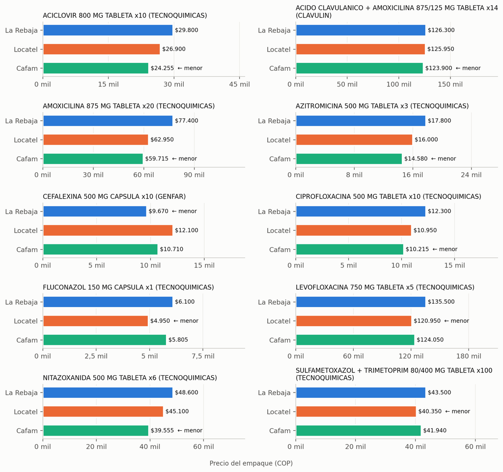

Figura 1: Precio de cada presentación comparable por comercio (COP, ejecución de referencia).

```python
datos = pd.read_sql_query("""
    SELECT p.descripcion, o.id_comercio, MIN(o.precio) AS precio
    FROM observaciones o
    JOIN anuncios  a ON a.id_comercio = o.id_comercio AND a.sku_comercio = o.sku_comercio
    JOIN productos p ON p.id_producto = a.id_producto
    WHERE o.id_ejecucion = :e AND a.comparable = 1 AND o.precio IS NOT NULL
    GROUP BY p.descripcion, o.id_comercio""", con, params={"e": EJEC})

if datos.empty:
    print("Aún no hay presentaciones comparables cargadas (correspondencia.csv).")
else:
    productos_lista = sorted(datos["descripcion"].unique())
    n = len(productos_lista); columnas = 2; filas = -(-n // columnas)
    fig, ejes = plt.subplots(filas, columnas, figsize=(10, 1.75 * filas + 0.6), squeeze=False)
    for eje, prod in zip(ejes.flat, productos_lista):
        d = datos[datos["descripcion"] == prod].set_index("id_comercio").reindex(ORDEN)
        minimo = d["precio"].min()
        eje.barh([NOMBRES[c] for c in d.index], d["precio"], color=[COLORES[c] for c in d.index],
                 height=0.62, edgecolor="#fcfcfb", linewidth=2)
        for i, (c, v) in enumerate(d["precio"].items()):
            if pd.notna(v):
                eje.text(v, i, " " + cop(v) + ("  ← menor" if v == minimo else ""),
                         va="center", fontsize=8, color="#0b0b0b")
        eje.set_title(textwrap.fill(prod, 55), fontsize=9, loc="left", color="#0b0b0b")
        eje.set_xlim(0, d["precio"].max() * 1.55); eje.invert_yaxis()
        eje.xaxis.set_major_locator(plt.MaxNLocator(4))   # pocas marcas para que no se monten
        eje.xaxis.set_major_formatter(lambda x, _: f"{x/1000:g} mil".replace(".", ","))
        eje.grid(axis="y", visible=False)
    for eje in list(ejes.flat)[n:]:
        eje.axis("off")
    fig.supxlabel("Precio del empaque (COP)", fontsize=9, color="#52514e")
    fig.tight_layout()
    plt.show()
```

Cada panel es una presentación y cada barra el precio del empaque en un comercio, con el mismo color para cada comercio en todo el documento. A simple vista, la barra de La Rebaja es la más larga en 9 de las 10 presentaciones, y las de Cafam y Locatel suelen quedar muy cerca entre sí. En Clavulin las tres barras son casi iguales.

Limitaciones: cada panel tiene su propia escala (no se deben comparar longitudes entre presentaciones distintas); es una sola fecha, y ese día Cafam tenía un descuento del 10 %; y es el precio publicado en línea, sin costo de envío.

**Código**

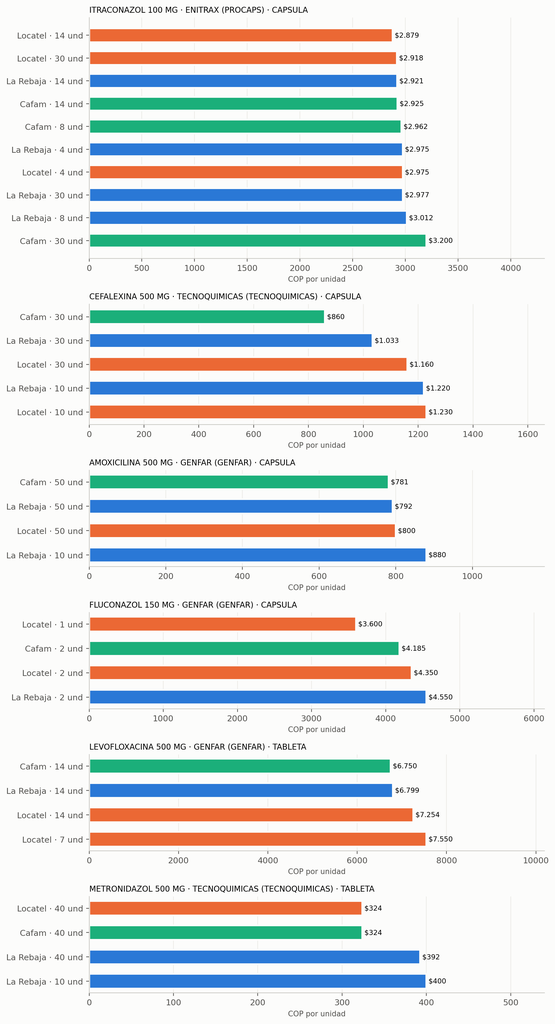

Figura 2: Precio por unidad de contenido en productos con varios tamaños (cada panel tiene su propia unidad).

```python
if p5.empty:
    print("No hay productos con dos o más tamaños en la ejecución de referencia.")
else:
    # Se muestran 6 productos, uno por principio activo: los que tienen más tamaños
    # distintos y, entre ellos, los que están en más comercios
    clave = ["principio_activo", "concentracion", "laboratorio", "marca", "forma", "unidad_comparacion"]
    resumen = (p5.groupby(clave, dropna=False)
                 .agg(tamanos=("cantidad", "nunique"), comercios=("id_comercio", "nunique"),
                      barras=("precio", "size"))
                 .sort_values(["tamanos", "comercios", "barras"], ascending=False, kind="stable")
                 .reset_index().drop_duplicates("principio_activo").head(6))
    top = [tuple(fila) for fila in resumen[clave].itertuples(index=False)]
    def filas_de(k):
        m = pd.Series(True, index=p5.index)
        for col, val in zip(clave, k):
            m &= (p5[col] == val) | (p5[col].isna() & pd.isna(val))
        return p5[m].sort_values("precio_por_unidad")
    # el alto de cada panel depende de cuántas barras tiene
    barras = [len(filas_de(k)) for k in top]
    fig, ejes = plt.subplots(len(top), 1, figsize=(9, sum(0.32 * n + 1.1 for n in barras)),
                             squeeze=False, gridspec_kw={"height_ratios": barras})
    for eje, k in zip(ejes.flat, top):
        d = filas_de(k)
        etiquetas = [f"{NOMBRES.get(c, c)} · {q:g} {k[5] if k[5] == 'mL' else 'und'}"
                     for c, q in zip(d["id_comercio"], d["cantidad"])]
        # posiciones numéricas: dos anuncios pueden tener la misma etiqueta
        # (mismo comercio y tamaño) y deben quedar en barras distintas
        posiciones = range(len(d))
        eje.barh(posiciones, d["precio_por_unidad"], color=[COLORES.get(c, "#888") for c in d["id_comercio"]],
                 height=0.6, edgecolor="#fcfcfb", linewidth=2)
        eje.set_yticks(posiciones, etiquetas)
        for i, v in enumerate(d["precio_por_unidad"]):
            eje.text(v, i, " " + cop(v), va="center", fontsize=8)
        eje.set_title(f"{k[0]} {k[1] or ''} · {k[3] or ''} ({k[2] or ''}) · {k[4] or ''}", fontsize=9, loc="left")
        eje.set_xlabel(f"COP por {k[5]}", fontsize=8.5)
        eje.set_xlim(0, d["precio_por_unidad"].max() * 1.35); eje.invert_yaxis(); eje.grid(axis="y", visible=False)
    fig.tight_layout()
    plt.show()
```

Cada panel es un mismo producto (principio activo, concentración, laboratorio, marca y forma) vendido en varios tamaños, con las barras ordenadas de menor a mayor precio por unidad. Se eligió un producto por principio activo, entre los que tienen más tamaños y están en los tres comercios. El gráfico muestra que el empaque grande no siempre gana:

- En la cefalexina MK la caja de 30 sale más barata por cápsula que la de 10 en La Rebaja y en Locatel, los dos comercios que venden ambos tamaños, y la más barata de todas es la caja de 30 de Cafam ($860 por cápsula).
- En Enitrax todas las opciones están entre $2.879 y $3.200 por cápsula, y la caja de 30 de Cafam es la más cara por unidad. Aquí importa más el comercio que el tamaño.
- En el fluconazol Genfar la caja de 1 cápsula de Locatel ($3.600) sale más barata por cápsula que las cajas de 2 de los tres comercios (entre $4.185 y $4.550 por cápsula).
- En el metronidazol MK la caja de 40 cuesta lo mismo por tableta en Locatel y en Cafam ($324), y en La Rebaja casi lo mismo en caja de 40 o de 10 ($392 y $400).

**Código**

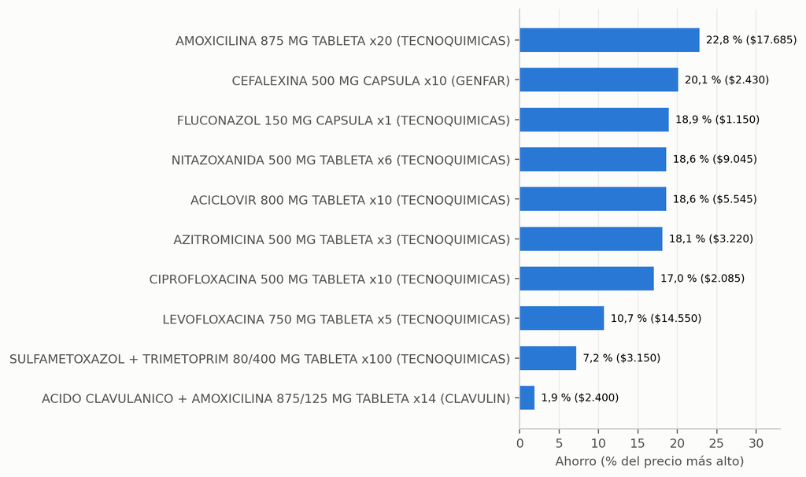

Figura 3: Ahorro potencial al comprar en el comercio más económico frente al más caro (misma presentación, misma ejecución).

```python
if p4.empty:
    print("Aún no hay presentaciones comparables cargadas.")
else:
    d = p4.sort_values("ahorro_pct")
    fig, eje = plt.subplots(figsize=(8.5, 0.42 * len(d) + 1))
    eje.barh(d["descripcion"], d["ahorro_pct"], color="#2a78d6", height=0.6)
    for i, (pct, cop_) in enumerate(zip(d["ahorro_pct"], d["ahorro_cop"])):
        eje.text(pct, i, f"  {pct:.1f} % ({cop(cop_)})".replace(".", ",", 1), va="center", fontsize=8)
    eje.set_xlabel("Ahorro (% del precio más alto)")
    eje.set_xlim(0, max(d["ahorro_pct"].max() * 1.45, 5)); eje.grid(axis="y", visible=False)
    fig.tight_layout()
    plt.show()
```

El gráfico ordena las presentaciones por el ahorro de comprar en el comercio más barato frente al más caro, con el ahorro en pesos al lado. Vale la pena buscar el comercio más barato en siete de ellas, que van de 17 % a 22,8 % (amoxicilina 875 mg, cefalexina, fluconazol, nitazoxanida, aciclovir, azitromicina y ciprofloxacina). En Clavulin casi da igual dónde comprar (1,9 %).

Limitaciones: compara el precio más barato con el más caro de esa ejecución; si alguien ya iba a comprar en el comercio de precio intermedio, su ahorro sería menor. El porcentaje no dice cuánta plata es: en el fluconazol el 18,9 % son $1.150, y en la amoxicilina 875 mg el 22,8 % son $17.685. Tampoco incluye el costo de envío ni la disponibilidad en cada ciudad.

# 7 Limitaciones y conclusiones

## 7.1 Limitaciones

- **Promociones.** El 4 de octubre ninguno de los 30 precios comparables era promocional. El 9 de octubre lo eran 9 de los 30: ocho de Cafam, todos con 10 % de descuento, y la cefalexina de La Rebaja, con 25 %. En toda la categoría, ese día estaban en promoción 122 de los 228 productos de Cafam, 37 de los 372 de La Rebaja y 6 de los 297 de Locatel. Las promociones cambiaron quién es el más barato (sección “Cambio de precios entre fechas”), así que los resultados no se pueden tomar como permanentes.
- **Alcance de los precios.** Son los precios publicados en línea en la fecha y hora de cada ejecución, con la configuración por defecto de cada sitio (sin escoger ciudad ni iniciar sesión) y sin costo de envío. No incluyen el precio en la droguería física ni descuentos para clientes registrados.
- **Pocas fechas.** Hay dos ejecuciones completas en fechas distintas (4 y 9 de octubre). Alcanzan para ver que los precios cambian, pero no para hablar de tendencias.
- **Fórmula médica y fraccionamiento.** Casi todos estos medicamentos requieren fórmula médica, y el precio no incluye la consulta. La Rebaja vende varios productos por blíster con el mismo código de la caja (32 códigos); esos casos no se compararon con la caja completa porque el número de unidades es distinto.
- **Correspondencia.** Se compararon solo presentaciones con el mismo EAN y el mismo número de unidades, verificadas con los nombres de los tres comercios. Esto da confianza porque el código de barras corresponde a un producto y un tamaño concretos. Los 49 anuncios sin EAN válido no pudieron entrar a la propuesta automática. Además, son 10 presentaciones elegidas por ser comunes: no permiten decir que un comercio es más barato en toda la categoría.
- **Delimitación de la categoría.** Se definió con reglas sobre el principio activo y la vía de administración (`categoria.py`). Algunas decisiones son discutibles: la furazolidona, la nifuroxazida y la rifaximina quedaron fuera por actuar en el intestino; los antipalúdicos como la hidroxicloroquina quedaron dentro por su código ATC; los óvulos y cremas vaginales quedaron fuera por ser de uso local. Para nueve marcas que Locatel publica sin principio activo se usó una lista revisada a mano.